# Низкозатратное цифровое предыскажение усилителя мощности

## Комплексная фазово-эквивариантная spline-memory модель с direct refinement

### Аннотация

Исследуется цифровое предыскажение нелинейного усилителя мощности для комплексного сигнала основной полосы. Рабочая модель должна учитывать амплитудно-фазовое искажение и короткую память, но оставаться пригодной для потокового и fixed-point выполнения.

Предложена причинная структура из трёх комплексных кусочно-линейных сплайн-ветвей. Сначала она получает устойчивую начальную калибровку через ILA, затем **те же коэффициенты** уточняются по локальной чувствительности полного каскада DPD→PA. Формула рабочего тракта при этом не меняется:

$$ z[n]=\sum_{m=0}^{2}x[n-m]C_m(|x[n-m]|). $$

На BlackBox validation direct refinement улучшил NMSE исходной ILA-модели с **−17.192 до −21.588 dB**. На заранее зарегистрированном untouched test waveform получено **−21.545 dB**, или **+4.337 dB** относительно ILA. Стоимость осталась прежней: **27 вещественных умножений, 28 сложений, 3 вычисления модуля и 6 чтений LUT** на комплексный отсчёт. При 12-bit программной арифметике потеря составила **0.014 dB**.

> **Граница доказательности:** все каскадные результаты получены через зафиксированный программный PA evaluator. Предыскажённый сигнал пока не подавался на физический усилитель. Notebook содержит встроенную копию train/validation capture; перед внешней отправкой необходимо подтвердить право распространения данных.

## 1. Исследовательский вопрос и вклад работы

### Исследовательский вопрос

Можно ли существенно уменьшить ошибку каскада, не добавляя ветви, задержки и нелинейные операции в уже дешёвый spline-memory DPD?

### Две проверяемые гипотезы

1. Короткая delay line и комплексные радиальные сплайны дают достаточно выразительный low-cost fast path:

   $$z[n]=\sum_{m=0}^{2}x[n-m]C_m(|x[n-m]|).$$
2. Основной остаток после ILA связан не только с архитектурой, но и с несовпадением ILA-функции потерь и конечной задачи каскада. Поэтому локальный direct refinement существующих коэффициентов может дать большой выигрыш без роста inference cost.

### Практический вклад

1. одна комплексная фазово-эквивариантная модель вместо независимых I/Q;
2. только два активных spline-узла на ветвь и отсчёт;
3. ILA как быстрое устойчивое начальное решение;
4. Якобиан, вычисленный конечными разностями, и регуляризованное direct-обновление;
5. раздельные train-fit и train-advisor блоки, validation без настройки шага;
6. one-shot untouched waveform после фиксации модели и критерия;
7. 16/14/12-bit проверка и точная streaming equivalence;
8. отрицательные структурные расширения сохранены как ablation evidence.

Работа не заявляет доказанную новую архитектуру относительно всей литературы. Результат — контролируемая комбинация известных методов и воспроизводимое доказательство её performance–complexity trade-off на данном evaluator.

### Суть идеи простыми словами

Рабочая формула DPD остаётся одной и той же до и после улучшения. Мы не добавляем новые ветви или нейроны. Вместо этого сначала получаем хороший начальный набор коэффициентов, а потом подправляем их так, чтобы уменьшалась ошибка именно на выходе всей цепочки DPD→PA. Поэтому калибровка становится точнее, а стоимость обработки каждого отсчёта не растёт.

```python
# Базовые импорты и настройки воспроизводимости.
from __future__ import annotations

import base64
import io
import hashlib
import json
import time
from pathlib import Path

import matplotlib.pyplot as plt
import numpy as np

np.random.seed(0)
np.set_printoptions(precision=5, suppress=True)
plt.style.use("seaborn-v0_8-whitegrid")
print("NumPy:", np.__version__)

# Единое оформление всех исследовательских рисунков.
plt.rcParams.update({
    "figure.dpi": 110,
    "axes.titlesize": 13,
    "axes.labelsize": 11,
    "legend.fontsize": 9,
})
```

```
NumPy: 2.5.1
```

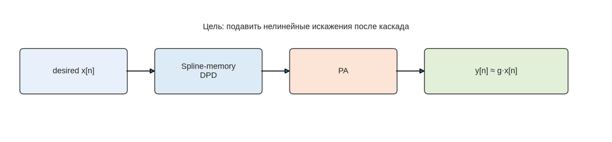

```python
# Физическая постановка: DPD предварительно изменяет desired-сигнал.
from matplotlib.patches import FancyBboxPatch, FancyArrowPatch

fig, ax = plt.subplots(figsize=(12.5, 3.0))
ax.set_xlim(0, 12.5)
ax.set_ylim(0, 3)
ax.axis("off")

blocks = [
    (0.35, 1.02, 2.15, 0.95, "desired x[n]", "#E8F1FB"),
    (3.15, 1.02, 2.15, 0.95, "Spline-memory\nDPD", "#DDEBF7"),
    (5.95, 1.02, 2.15, 0.95, "PA", "#FCE4D6"),
    (8.75, 1.02, 2.90, 0.95, "y[n] ≈ g·x[n]", "#E2F0D9"),
]
for x0, y0, width, height, label, color in blocks:
    patch = FancyBboxPatch(
        (x0, y0), width, height,
        boxstyle="round,pad=0.04,rounding_size=0.08",
        facecolor=color, edgecolor="0.25", linewidth=1.2,
    )
    ax.add_patch(patch)
    ax.text(x0 + width / 2, y0 + height / 2, label, ha="center", va="center", fontsize=12)
for start, end in [((2.5, 1.5), (3.15, 1.5)), ((5.3, 1.5), (5.95, 1.5)), ((8.1, 1.5), (8.75, 1.5))]:
    ax.add_patch(FancyArrowPatch(start, end, arrowstyle="-|>", mutation_scale=15, lw=1.3))
ax.text(6.25, 2.45, "Цель: подавить нелинейные искажения после каскада", ha="center", fontsize=12)
plt.tight_layout()
plt.show()
```

## 2. Откуда возник выбранный подход

В основе решения лежат четыре направления предыдущих работ.

| Источник идеи | Что использовано в данной работе |
| --- | --- |
| Memory Polynomial и GMP | Комплексные нелинейные признаки с короткой памятью; GMP используется только как вспомогательная модель PA. |
| Indirect Learning Architecture | Постдистортер обучается по парам $y/g\rightarrow x$, но финальный DPD проверяется на новом desired-входе. |
| Spline/LUT DPD | Локальные комплексные control points и интерполяция между соседними узлами дают регулярный малозатратный тракт. |
| Воспроизводимые DPD-frameworks | Отделение обучения PA evaluator от калибровки и проверки DPD, фиксированные split и метрики. |

Особенно близка структурная идея spline memory polynomial из работы P. P. Campo et al.: параллельные комплексные spline-LUT ветви позволяют учесть память при существенно меньшей стоимости, чем полный полиномиальный словарь. В нашей реализации используются линейные сплайны, квантильные узлы и одно комплексное ridge-решение.

Ключевые первичные источники приведены в конце notebook. Их результаты не переносятся в нашу таблицу качества: разные PA и протоколы нельзя смешивать в единый рейтинг.

## 3. Экспериментальный протокол

Исследование разделено на три этапа.

**A. Идентификация вспомогательной модели PA**

$$x_{train}\rightarrow \widehat P\rightarrow \widehat y_{train}\approx y_{train}.$$

После обучения $\widehat P$ замораживается. Его стоимость не входит в бюджет рабочего DPD.

**B. Начальная ILA-калибровка**

$$y_{train}/g\rightarrow D_{post}\rightarrow x_{train}.$$

ILA даёт быстрое линейное по коэффициентам начальное решение. Финальная проверка при этом всегда начинается с desired-сигнала:

$$x\rightarrow DPD\rightarrow \widehat P\rightarrow \widehat y \quad\text{vs.}\quad gx.$$

**C. Direct refinement**

Не меняя сплайн-архитектуру, коэффициенты уточняются по ошибке полного каскада $\widehat P(D(x))-gx$. Измеренный $y_{val}$ не подаётся на вход DPD. Validation используется только для итоговой диагностики зафиксированного числа итераций, а не для вычисления обновлений или ранней остановки.

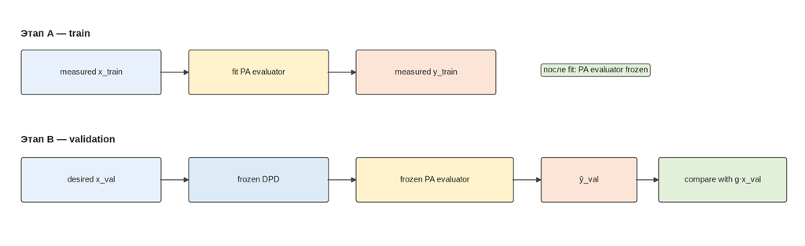

```python
# Схема потока данных и границы обучения.
fig, ax = plt.subplots(figsize=(13.5, 4.2))
ax.set_xlim(0, 13.5)
ax.set_ylim(0, 4.2)
ax.axis("off")

def draw_box(x0, y0, text, color, width=2.3):
    box = FancyBboxPatch((x0, y0), width, 0.72, boxstyle="round,pad=0.04",
                         facecolor=color, edgecolor="0.3")
    ax.add_patch(box)
    ax.text(x0 + width/2, y0 + 0.36, text, ha="center", va="center", fontsize=10)

def arrow(x1, y1, x2, y2):
    ax.add_patch(FancyArrowPatch((x1, y1), (x2, y2), arrowstyle="-|>",
                                 mutation_scale=13, color="0.25"))

ax.text(0.25, 3.65, "Этап A — train", weight="bold", fontsize=12)
draw_box(0.3, 2.65, "measured x_train", "#E8F1FB")
draw_box(3.15, 2.65, "fit PA evaluator", "#FFF2CC")
draw_box(6.0, 2.65, "measured y_train", "#FCE4D6")
arrow(2.6, 3.01, 3.15, 3.01); arrow(5.45, 3.01, 6.0, 3.01)
ax.text(9.15, 3.01, "после fit: PA evaluator frozen", fontsize=10,
        bbox=dict(boxstyle="round", fc="#E2F0D9", ec="0.4"))

ax.text(0.25, 1.75, "Этап B — validation", weight="bold", fontsize=12)
draw_box(0.3, 0.72, "desired x_val", "#E8F1FB")
draw_box(3.15, 0.72, "frozen DPD", "#DDEBF7")
draw_box(6.0, 0.72, "frozen PA evaluator", "#FFF2CC", width=2.6)
draw_box(9.15, 0.72, "ŷ_val", "#FCE4D6", width=1.55)
draw_box(11.15, 0.72, "compare with g·x_val", "#E2F0D9", width=2.1)
arrow(2.6, 1.08, 3.15, 1.08); arrow(5.45, 1.08, 6.0, 1.08)
arrow(8.6, 1.08, 9.15, 1.08); arrow(10.7, 1.08, 11.15, 1.08)
plt.tight_layout()
plt.show()
```

```python
# Встроенные train/validation массивы BlackBoxData (сжатый NPZ, base64).
# Генератор notebook подставляет payload перед сохранением файла.
EMBEDDED_DATA_B64 = """UEsDBC0AAAAIAAAAIQDrcdnL//////////8PABQAdHJhaW5feF9yYXcubnB5…="""


def load_embedded_splits() -> dict[str, np.ndarray]:
    """Decode the portable train/validation payload from this notebook.

    Returns:
        A dictionary with raw complex ``train_x``, ``train_y``,
        ``val_x`` and ``val_y`` arrays plus a human-readable source.
    """
    binary = base64.b64decode(EMBEDDED_DATA_B64.encode("ascii"))
    with np.load(io.BytesIO(binary), allow_pickle=False) as payload:
        result = {name: np.asarray(payload[name], dtype=np.complex128) for name in (
            "train_x_raw", "train_y_raw", "val_x_raw", "val_y_raw"
        )}
    result["source"] = "embedded BlackBoxData train/validation payload"
    return result


print("embedded payload ready; source data are portable with this notebook")
```

```
embedded payload ready; source data are portable with this notebook
```

## 4. Данные и дисциплина разбиения

Используется один BlackBox capture с комплексными массивами `x` и `y`:

- train: 92 000 отсчётов, исходный диапазон `5000:97000`;
- validation: 23 000 отсчётов, `97000:120000`;
- untouched test: 125 760 отсчётов, начиная с `120000`.

Топология и $K$ исторически выбирались по validation, поэтому validation не является независимой финальной оценкой. После фиксации direct-кандидата, метрики, warm-up и acceptance gate был один раз открыт только желаемый $x_{test}$. Измеренный $y_{test}$ не открывался: test остаётся проверкой нового waveform через тот же frozen PA evaluator, а не физическим DPD-измерением.

Train/validation встроены для воспроизводимости notebook. Test samples не встраиваются; ниже используется только сохранённый агрегированный one-shot отчёт.

```python
# Фиксированные параметры запуска. В portable-режиме менять пути не нужно:
# данные уже находятся внутри notebook.
PROJECT_CANDIDATES = [Path.cwd(), *Path.cwd().parents]
PROJECT_ROOT = next(
    (p for p in PROJECT_CANDIDATES
     if (p / "data/private/blackbox_v3/selection").is_dir()),
    Path.cwd(),
)
SELECTION_DIR = PROJECT_ROOT / "data/private/blackbox_v3/selection"
USE_EMBEDDED_DATA = True
MAT_PATH = None  # пример: Path("/content/BlackBoxData.mat")
print("external project data directory detected =", SELECTION_DIR.is_dir())
print("USE_EMBEDDED_DATA =", USE_EMBEDDED_DATA)
```

```
external project data directory detected = True
USE_EMBEDDED_DATA = True
```

```python
def read_iq_csv(path: Path) -> np.ndarray:
    """Read a two-column ``I,Q`` CSV and return ``I + jQ`` samples.

    Args:
        path: CSV file with a header and two numeric columns.

    Returns:
        One-dimensional finite complex128 vector.
    """
    raw = np.loadtxt(path, delimiter=",", skiprows=1)
    if raw.ndim != 2 or raw.shape[1] < 2:
        raise ValueError(f"Expected I,Q columns in {path}")
    signal = np.asarray(raw[:, 0] + 1j * raw[:, 1], dtype=np.complex128)
    if not np.all(np.isfinite(signal)):
        raise ValueError(f"Non-finite samples in {path}")
    return signal


def load_mat_splits(path: Path) -> dict[str, np.ndarray]:
    """Load the optional MAT fallback and apply the frozen split.

    The source variables are validated, while ``eRef`` is retained only
    for the shape check and is intentionally not used by the model.
    """
    from scipy.io import loadmat

    payload = loadmat(path)
    vectors = {}
    for name in ("x", "y", "eRef"):
        if name not in payload:
            raise ValueError(f"MAT file lacks {name}")
        value = np.asarray(payload[name]).reshape(-1)
        if not np.iscomplexobj(value):
            raise ValueError(f"MAT variable {name} is not complex")
        vectors[name] = np.asarray(value, dtype=np.complex128)
    if len({v.size for v in vectors.values()}) != 1:
        raise ValueError("x, y and eRef must have equal lengths")
    return {
        "train_x_raw": vectors["x"][5000:97000],
        "train_y_raw": vectors["y"][5000:97000],
        "val_x_raw": vectors["x"][97000:120000],
        "val_y_raw": vectors["y"][97000:120000],
        "source": path,
    }


def load_blackbox_splits(selection_dir: Path, mat_path: Path | None) -> dict[str, np.ndarray]:
    """Load embedded data or explicit CSV/MAT files with clear errors."""
    if USE_EMBEDDED_DATA:
        return load_embedded_splits()
    files = {
        "train_x_raw": selection_dir / "train_input.csv",
        "train_y_raw": selection_dir / "train_output.csv",
        "val_x_raw": selection_dir / "val_input.csv",
        "val_y_raw": selection_dir / "val_output.csv",
    }
    if all(path.is_file() for path in files.values()):
        result = {name: read_iq_csv(path) for name, path in files.items()}
        result["source"] = selection_dir
        return result
    if mat_path is not None and Path(mat_path).is_file():
        return load_mat_splits(mat_path)
    raise FileNotFoundError(
        "USE_EMBEDDED_DATA=False, но данные не найдены. "
        "Укажите каталог с четырьмя I,Q CSV в SELECTION_DIR или "
        "существующий BlackBoxData.mat в MAT_PATH."
    )


raw = load_blackbox_splits(SELECTION_DIR, MAT_PATH)
train_x_raw, train_y_raw = raw["train_x_raw"], raw["train_y_raw"]
val_x_raw, val_y_raw = raw["val_x_raw"], raw["val_y_raw"]
assert train_x_raw.size == train_y_raw.size == 92000
assert val_x_raw.size == val_y_raw.size == 23000
print("source:", raw["source"])
print("train:", train_x_raw.shape, "validation:", val_x_raw.shape)
print("raw train input peak:", np.max(np.abs(train_x_raw)))
```

```
source: embedded BlackBoxData train/validation payload
train: (92000,) validation: (23000,)
raw train input peak: 18336.09364068585
```

## 5. Выравнивание, нормировка и комплексный gain

Все параметры preprocessing оцениваются **только по train**:

1. integer delay максимизирует модуль нормированной комплексной корреляции;
2. общий масштаб равен максимуму $|x_{train}|$;
3. комплексный линейный gain оценивается как

$$ g=\frac{\sum_n x^*[n]y[n]}{\sum_n|x[n]|^2}. $$

Те же delay, scale и gain затем без переоценки применяются к validation. Fractional delay ниже показан только как диагностика параболической интерполяцией вокруг корреляционного максимума.

```
train-only integer delay = 0 samples
fractional-delay diagnostic = -0.014700 samples (not applied)
alignment peak score = 0.986855
train-only scale = 18336.093641
train-only complex gain = 0.99962078 +0.00067656j
normalized peaks: 1.000000 1.093883 0.971956 1.085530
```

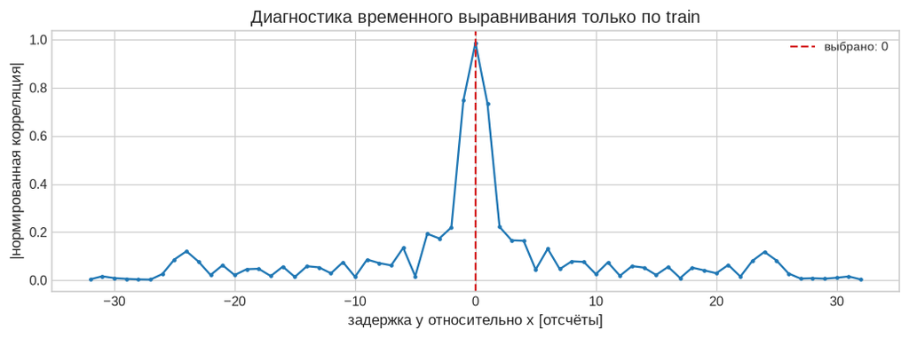

```python
# Alignment, normalization и gain оцениваются только на train.
def overlap_at_delay(x: np.ndarray, y: np.ndarray, delay: int):
    """Return overlapping vectors when y is delayed by ``delay`` vs x."""
    if delay > 0:
        return x[:-delay], y[delay:]
    if delay < 0:
        return x[-delay:], y[:delay]
    return x, y


def normalized_alignment_score(x: np.ndarray, y: np.ndarray, delay: int) -> float:
    """Return magnitude of normalized complex correlation at one delay."""
    xa, ya = overlap_at_delay(x, y, delay)
    denominator = np.sqrt(np.vdot(xa, xa).real * np.vdot(ya, ya).real)
    return float(abs(np.vdot(xa, ya)) / denominator)


ALIGNMENT_DELAYS = np.arange(-32, 33)
alignment_scores = np.array([
    normalized_alignment_score(train_x_raw, train_y_raw, int(delay))
    for delay in ALIGNMENT_DELAYS
])
integer_delay = int(ALIGNMENT_DELAYS[np.argmax(alignment_scores)])
peak_index = int(np.argmax(alignment_scores))
fractional_offset = 0.0
if 0 < peak_index < alignment_scores.size - 1:
    left_score, peak_score, right_score = alignment_scores[peak_index - 1:peak_index + 2]
    curvature = left_score - 2.0 * peak_score + right_score
    if abs(curvature) > 1e-15:
        fractional_offset = float(0.5 * (left_score - right_score) / curvature)
fractional_delay_diagnostic = integer_delay + fractional_offset

# Один train-only integer delay применяется без переоценки на validation.
train_x_aligned, train_y_aligned = overlap_at_delay(train_x_raw, train_y_raw, integer_delay)
val_x_aligned, val_y_aligned = overlap_at_delay(val_x_raw, val_y_raw, integer_delay)

TRAIN_INPUT_PEAK = float(np.max(np.abs(train_x_aligned)))
train_x = train_x_aligned / TRAIN_INPUT_PEAK
train_y = train_y_aligned / TRAIN_INPUT_PEAK
val_x = val_x_aligned / TRAIN_INPUT_PEAK
val_y = val_y_aligned / TRAIN_INPUT_PEAK

gain = np.vdot(train_x, train_y) / np.vdot(train_x, train_x)
print(f"train-only integer delay = {integer_delay} samples")
print(f"fractional-delay diagnostic = {fractional_delay_diagnostic:+.6f} samples (not applied)")
print(f"alignment peak score = {alignment_scores[peak_index]:.6f}")
print(f"train-only scale = {TRAIN_INPUT_PEAK:.6f}")
print(f"train-only complex gain = {gain.real:.8f} {gain.imag:+.8f}j")
print("normalized peaks:", *(f"{np.max(np.abs(v)):.6f}" for v in (train_x, train_y, val_x, val_y)))

fig, ax = plt.subplots(figsize=(9.5, 3.6))
ax.plot(ALIGNMENT_DELAYS, alignment_scores, marker=".", ms=4)
ax.axvline(integer_delay, color="tab:red", ls="--", label=f"выбрано: {integer_delay}")
ax.set(xlabel="задержка y относительно x [отсчёты]", ylabel="|нормированная корреляция|",
       title="Диагностика временного выравнивания только по train")
ax.legend()
plt.tight_layout()
plt.show()
```

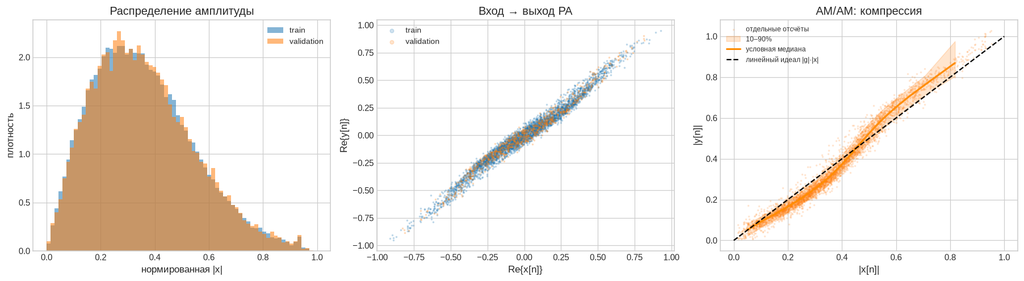

```
Минимум отсчётов в AM/AM bin: 2875
Полоса 10–90% показывает наблюдаемый разброс, а не доверительный интервал.
```

```python
# Проверка сопоставимости train/validation и объяснение AM/AM-разброса.
def quantile_binned_statistics(radius, values, bin_count=32):
    """Return conditional median and 10/90 percentiles in quantile bins."""
    radius = np.asarray(radius, dtype=float)
    values = np.asarray(values, dtype=float)
    if radius.shape != values.shape or radius.ndim != 1:
        raise ValueError("radius and values must be equal one-dimensional arrays")
    edges = np.unique(np.quantile(radius, np.linspace(0.0, 1.0, bin_count + 1)))
    centers, medians, lower, upper, counts = [], [], [], [], []
    for index, (left, right) in enumerate(zip(edges[:-1], edges[1:])):
        mask = (radius >= left) & (radius < right)
        if index == edges.size - 2:
            mask = (radius >= left) & (radius <= right)
        if np.count_nonzero(mask) < 10:
            continue
        centers.append(np.median(radius[mask]))
        medians.append(np.median(values[mask]))
        lower.append(np.quantile(values[mask], 0.10))
        upper.append(np.quantile(values[mask], 0.90))
        counts.append(np.count_nonzero(mask))
    return {name: np.asarray(value) for name, value in {
        "center": centers, "median": medians, "q10": lower,
        "q90": upper, "count": counts,
    }.items()}


sample = slice(None, None, 25)
fig, axes = plt.subplots(1, 3, figsize=(16.5, 4.6))

amplitude_bins = np.linspace(
    0, max(np.max(np.abs(train_x)), np.max(np.abs(val_x))), 70
)
axes[0].hist(np.abs(train_x), bins=amplitude_bins, density=True,
             alpha=0.55, label="train")
axes[0].hist(np.abs(val_x), bins=amplitude_bins, density=True,
             alpha=0.55, label="validation")
axes[0].set(xlabel="нормированная |x|", ylabel="плотность",
            title="Распределение амплитуды")
axes[0].legend()

# Возвращён исходный scatter: один маркер соответствует одному временному отсчёту.
axes[1].scatter(train_x.real[sample], train_y.real[sample], s=2,
                alpha=0.20, color="tab:blue", label="train")
axes[1].scatter(val_x.real[sample], val_y.real[sample], s=2,
                alpha=0.20, color="tab:orange", label="validation")
axes[1].set(xlabel="Re{x[n]}", ylabel="Re{y[n]}",
            title="Вход → выход PA")
axes[1].legend(markerscale=3)

# Исходные точки AM/AM оставлены оранжевыми; диапазон 10–90% не скрывает их.
train_amam = quantile_binned_statistics(np.abs(train_x), np.abs(train_y))
axes[2].scatter(np.abs(train_x)[sample], np.abs(train_y)[sample], s=2,
                alpha=0.13, color="tab:orange", label="отдельные отсчёты")
axes[2].fill_between(train_amam["center"], train_amam["q10"],
                     train_amam["q90"], color="tab:orange", alpha=0.20,
                     label="10–90%")
axes[2].plot(train_amam["center"], train_amam["median"],
             color="darkorange", lw=2.0, label="условная медиана")
r_grid = np.linspace(0, max(np.max(np.abs(train_x)), np.max(np.abs(val_x))), 250)
axes[2].plot(r_grid, abs(gain) * r_grid, color="black", ls="--",
             label="линейный идеал |g|·|x|")
axes[2].set(xlabel="|x[n]|", ylabel="|y[n]|", title="AM/AM: компрессия")
axes[2].legend(fontsize=8)
plt.tight_layout()
plt.show()

print("Минимум отсчётов в AM/AM bin:", int(train_amam["count"].min()))
print("Полоса 10–90% показывает наблюдаемый разброс, а не доверительный интервал.")
```

### Как читать точки на графиках PA

- На графике **«Вход → выход PA»** каждая точка соответствует одному и тому же временному отсчёту $n$: по горизонтали показана $\operatorname{Re}\{x[n]\}$, по вертикали — $\operatorname{Re}\{y[n]\}$. Синие точки относятся к train, оранжевые — к validation. Это проекция комплексных I/Q-отсчётов, а не отдельные символы созвездия.
- На графике **AM/AM** каждая оранжевая точка — пара $(|x[n]|,|y[n]|)$. Поэтому вертикальный разброс при одном $|x|$ может появляться из-за памяти PA и различного соседнего I/Q-контекста.
- Оранжевая полоса 10–90% содержит центральные 80% выходных амплитуд внутри каждого диапазона $|x|$. Она делает разброс читаемым, но не заменяет и не «исправляет» исходные точки.

### Как читать разброс

График `Re{g·x} → Re{y}` и AM/AM являются проекциями системы с памятью на две координаты. Реальный PA описывается скорее как

$$y[n]=f(x[n],x[n-1],x[n-2],\ldots),$$

поэтому одинаковое текущее $|x[n]|$ не обязано давать одинаковое $|y[n]|$. Условная медиана показывает центральную AM/AM-зависимость, а полоса 10–90% сохраняет информацию о памяти, фазовом окружении и измерительном разбросе. Такое агрегирование делает рисунок читаемее, но не выдаётся за физическое уменьшение дисперсии.

## 6. Метрика качества

Основная временная метрика — pooled complex NMSE:

$$ \mathrm{NMSE}_{dB}=10\log_{10} \frac{\sum_n|\widehat y[n]-y_{ref}[n]|^2} {\sum_n|y_{ref}[n]|^2}. $$

Более отрицательное значение означает меньшую нормированную мощность ошибки. Первые causal warm-up отсчёты исключаются. Отдельная QAM EVM не вычисляется: без символов, демодуляции, синхронизации и эквализации это было бы неверной трактовкой нормированной временной ошибки.

### Интуитивная трактовка

NMSE сравнивает мощность ошибки с мощностью желаемого сигнала. Например, $-20$ dB соответствует относительной мощности ошибки около 1%. Поэтому $-21.6$ dB лучше, чем $-17.2$ dB: в первом случае ошибка занимает меньшую долю мощности сигнала.

```python
def pooled_nmse_db(estimate: np.ndarray, reference: np.ndarray, warmup: int = 0) -> float:
    """Return pooled complex NMSE in dB after a causal warm-up.

    Args:
        estimate: Predicted complex output.
        reference: Desired/reference complex output.
        warmup: Number of record-start samples excluded from scoring.

    Returns:
        ``10*log10(MSE / reference_power)``.
    """
    estimate = np.asarray(estimate, dtype=np.complex128)
    reference = np.asarray(reference, dtype=np.complex128)
    if estimate.shape != reference.shape or estimate.ndim != 1:
        raise ValueError("metric vectors must be equal 1-D arrays")
    e = estimate[warmup:] - reference[warmup:]
    ref = reference[warmup:]
    return float(10.0 * np.log10(np.mean(np.abs(e) ** 2) / np.mean(np.abs(ref) ** 2)))


def normalized_rms_error_db(estimate: np.ndarray, reference: np.ndarray, warmup: int = 0) -> float:
    """Return time-domain normalized RMS error; equal to NMSE in dB."""
    e = np.asarray(estimate)[warmup:] - np.asarray(reference)[warmup:]
    ref = np.asarray(reference)[warmup:]
    return float(20.0 * np.log10(np.sqrt(np.mean(np.abs(e) ** 2)) / np.sqrt(np.mean(np.abs(ref) ** 2))))


def summary(signal: np.ndarray) -> dict[str, float]:
    """Summarize RMS amplitude, peak amplitude and PAPR of a signal."""
    power = float(np.mean(np.abs(signal) ** 2))
    peak = float(np.max(np.abs(signal)))
    return {
        "rms": float(np.sqrt(power)),
        "peak": peak,
        "papr_db": float(10.0 * np.log10(peak * peak / power)),
    }


def metric_row(name: str, estimate: np.ndarray, reference: np.ndarray, warmup: int) -> dict:
    """Build one readable report row from the common metric functions."""
    return {
        "name": name,
        "nmse_db": pooled_nmse_db(estimate, reference, warmup),
        **summary(estimate),
    }


# Algebraic identity check; this is why no independent EVM column is shown.
_metric_probe = np.array([1 + 1j, 0.5 - 0.2j])
assert abs(pooled_nmse_db(0.9 * _metric_probe, _metric_probe)
           - normalized_rms_error_db(0.9 * _metric_probe, _metric_probe)) < 1e-12
```

## 7. Вспомогательная модель усилителя

Для воспроизводимого каскада используется причинный Generalized Memory Polynomial:

$$ \begin{aligned} \widehat y[n]={}&\sum_{k,q}a_{kq}x[n-q]|x[n-q]|^k\\ &+\sum_{k,q,l}b_{kql}x[n-q]|x[n-q-l]|^k\\ &+\sum_{k,q,l}c_{kql}x[n-q]|x[n-q+l]|^k. \end{aligned} $$

Leading-envelope terms допускаются только когда итоговая зависимость остаётся причинной. Коэффициенты оцениваются комплексной ridge-регрессией на train и после fit замораживаются. Это **evaluator эксперимента**, а не часть рабочего DPD; его стоимость не входит в fast path.

### Зачем вообще нужна модель PA

В этом notebook нельзя многократно подавать каждый пробный сигнал на физический усилитель. Поэтому по измеренным парам $x\rightarrow y$ строится его программная копия. Она позволяет быстро сравнивать варианты DPD. GMP в формуле ниже — это набор нелинейных членов с разными задержками; он описывает как мгновенную нелинейность, так и короткую память PA.

```python
def causal_delay(signal: np.ndarray, delay: int) -> np.ndarray:
    """Apply a causal integer delay with zero padding at record start."""
    out = np.zeros_like(signal, dtype=np.complex128)
    if delay == 0:
        out[:] = signal
    elif delay > 0:
        out[delay:] = signal[:-delay]
    return out


def gmp_terms(ka=9, la=9, kb=3, lb=7, mb=3, kc=3, lc=7, mc=3):
    """Enumerate causal GMP terms as ``(branch, order, q, envelope_q)``."""
    terms = []
    for exponent in range(ka):
        for q in range(la):
            terms.append(("aligned", exponent, q, q))
    for exponent in range(1, kb + 1):
        for q in range(lb):
            for lag in range(1, mb + 1):
                terms.append(("lagging", exponent, q, q + lag))
    for exponent in range(1, kc + 1):
        for q in range(lc):
            for lead in range(1, mc + 1):
                if lead <= q:  # causal-leading policy
                    terms.append(("leading", exponent, q, q - lead))
    return tuple(terms)


def gmp_design(signal: np.ndarray, terms: tuple) -> np.ndarray:
    """Construct the dense complex GMP design matrix in term order."""
    signal = np.asarray(signal, dtype=np.complex128)
    columns = []
    for _branch, exponent, signal_delay, envelope_delay in terms:
        delayed = causal_delay(signal, signal_delay)
        if exponent == 0:
            columns.append(delayed)
        else:
            envelope = np.abs(causal_delay(signal, envelope_delay))
            columns.append(delayed * envelope ** exponent)
    return np.column_stack(columns)


def fit_complex_ridge(design: np.ndarray, target: np.ndarray, ridge: float) -> np.ndarray:
    """Fit complex coefficients with column scaling and ridge regularization.

    The data term is normalized by the number of samples, matching the
    frozen PA-selection protocol used for the BlackBox experiment.
    """
    design = np.asarray(design, dtype=np.complex128)
    target = np.asarray(target, dtype=np.complex128)
    column_rms = np.sqrt(np.mean(np.abs(design) ** 2, axis=0))
    if np.any(column_rms <= 0) or not np.all(np.isfinite(column_rms)):
        raise ValueError("invalid design column scale")
    # The project protocol minimizes mean squared error + ridge:
    # ||D c - q||²/N + ridge*||c||².  Dividing both data and target
    # by sqrt(N) is therefore part of the definition, not cosmetic
    # numerical scaling.
    normalization = np.sqrt(float(design.shape[0]))
    scaled = design / column_rms / normalization
    normalized_target = target / normalization
    if ridge > 0:
        regularizer = np.sqrt(ridge) * np.eye(
            scaled.shape[1], dtype=np.complex128
        )
        augmented = np.vstack((scaled, regularizer))
        augmented_target = np.concatenate(
            (normalized_target, np.zeros(scaled.shape[1], dtype=np.complex128))
        )
    else:
        augmented, augmented_target = scaled, normalized_target
    coeff_scaled = np.linalg.lstsq(augmented, augmented_target, rcond=None)[0]
    return coeff_scaled / column_rms


# Frozen evaluator configuration selected on the BlackBox validation split.
# The PA is auxiliary: its complexity is not the deployment DPD budget.
pa_terms = gmp_terms()
assert len(pa_terms) == 189
# Forward identification: measured PA input x -> measured output y.
started = time.perf_counter()
pa_design = gmp_design(train_x, pa_terms)
pa_coefficients = fit_complex_ridge(pa_design, train_y, ridge=1e-10)
pa_fit_seconds = time.perf_counter() - started
del pa_design
pa_train_hat = gmp_design(train_x, pa_terms) @ pa_coefficients
pa_val_design = gmp_design(val_x, pa_terms)
pa_val_hat = pa_val_design @ pa_coefficients
del pa_val_design
print(f"GMP terms: {len(pa_terms)} complex coefficients")
print(f"fit time: {pa_fit_seconds:.2f} s")
print(f"PA validation fidelity: {pooled_nmse_db(pa_val_hat, val_y, warmup=11):.3f} dB NMSE")
```

```
GMP terms: 189 complex coefficients
fit time: 8.12 s
PA validation fidelity: -28.590 dB NMSE
```

```python
# До DPD: каскад frozen PA на желаемом validation input.
PA_WARMUP = 9
DPD_WARMUP = 2
CASCADE_WARMUP = PA_WARMUP + DPD_WARMUP
ideal_val = gain * val_x
measured_no_dpd = metric_row("measured y (diagnostic)", val_y, ideal_val, CASCADE_WARMUP)
surrogate_no_dpd = metric_row("frozen PA, no DPD", pa_val_hat, ideal_val, CASCADE_WARMUP)
print(measured_no_dpd)
print(surrogate_no_dpd)
```

```
{'name': 'measured y (diagnostic)', 'nmse_db': -15.78064467142287, 'rms': 0.4096629648882422, 'peak': 1.0855304876366918, 'papr_db': 8.464306429911977}
{'name': 'frozen PA, no DPD', 'nmse_db': -16.010350840472285, 'rms': 0.4094811906023182, 'peak': 1.0540003577118497, 'papr_db': 8.212136018077079}
```

## 8. Предлагаемая spline-memory DPD

### 8.1 Архитектура

Для ветвей $m\in\{0,1,2\}$:

$$ z[n]=\sum_{m=0}^{2}x[n-m]C_m(r_m[n]), \qquad r_m[n]=|x[n-m]|. $$

$C_m(r)$ — комплексная кусочно-линейная функция. Для $r\in[r_k,r_{k+1}]$:

$$ C_m(r)=(1-\alpha)C_{m,k}+\alpha C_{m,k+1}, \qquad \alpha=\frac{r-r_k}{r_{k+1}-r_k}. $$

Таким образом, один комплексный коэффициент совместно задаёт амплитудную и фазовую коррекцию, а на отсчёте активны только два соседних узла каждой ветви.

### 8.2 Фазовая эквивариантность

Пусть $x'[n]=x[n]e^{j\varphi}$. Тогда $|x'[n-m]|=|x[n-m]|$, следовательно:

$$ \begin{aligned} D(xe^{j\varphi})[n] &=\sum_m x[n-m]e^{j\varphi}C_m(|x[n-m]|)\\ &=e^{j\varphi}D(x)[n]. \end{aligned} $$

Модель не привязана к произвольной ориентации I/Q-плоскости.

### 8.3 Почему квантильные узлы

Квантильное размещение даёт каждому интервалу примерно одинаковое число калибровочных отсчётов. Это улучшает обусловленность по сравнению с равномерными узлами, когда большая часть редких высокоамплитудных интервалов получает мало данных. Цена — менее равномерное разрешение по амплитуде, поэтому число узлов всё равно выбирается экспериментально.

### Интуитивное объяснение

Модель состоит из трёх одинаково устроенных ветвей. Первая работает с текущим отсчётом, вторая — с предыдущим, третья — с отсчётом два шага назад. Так учитывается короткая память усилителя.

Внутри каждой ветви стоит сплайн — ломаная линия, заданная небольшим числом узлов. Для каждого отсчёта нужно прочитать только два соседних узла и провести между ними линейную интерполяцию. Именно поэтому 24 узла не означают 24 умножения на каждую ветвь.

```python
def make_quantile_knots(signal: np.ndarray, count: int) -> np.ndarray:
    """Place strictly increasing interpolation knots by amplitude quantiles."""
    radius = np.abs(np.asarray(signal, dtype=np.complex128))
    unit = np.linspace(0.0, 1.0, count)
    knots = np.quantile(radius, unit)
    knots[0] = 0.0
    knots[-1] = np.max(radius)
    knots = np.unique(knots)
    if knots.size < 2 or np.any(np.diff(knots) <= 0):
        raise ValueError("quantile knots are not strictly increasing")
    return knots


def spline_coordinates(radius: np.ndarray, knots: np.ndarray):
    """Return left-knot indices and local linear interpolation weights."""
    clipped = np.clip(np.asarray(radius, dtype=float), knots[0], knots[-1])
    left = np.searchsorted(knots, clipped, side="right") - 1
    left = np.clip(left, 0, knots.size - 2)
    weight = (clipped - knots[left]) / (knots[left + 1] - knots[left])
    return left.astype(np.int64), weight


def spline_memory_design(signal: np.ndarray, knots: np.ndarray, branches: tuple[tuple[int, int], ...]) -> np.ndarray:
    """Build ``Phi[n,bK+k] = x[n-m] B_k(|x[n-d]|)`` for spline-memory DPD."""
    signal = np.asarray(signal, dtype=np.complex128)
    columns = []
    for signal_delay, envelope_delay in branches:
        delayed_signal = causal_delay(signal, signal_delay)
        delayed_envelope = causal_delay(signal, envelope_delay)
        left, weight = spline_coordinates(np.abs(delayed_envelope), knots)
        basis = np.zeros((signal.size, knots.size), dtype=float)
        rows = np.arange(signal.size)
        basis[rows, left] = 1.0 - weight
        basis[rows, left + 1] += weight
        columns.extend((delayed_signal[:, None] * basis).T)
    return np.column_stack(columns)


def fit_spline_memory_dpd(calibration_input, target, knots, branches, ridge):
    """Fit the ILA spline-memory coefficients on the causal steady region."""
    warmup = max(max(b) for b in branches)
    design = spline_memory_design(calibration_input, knots, branches)[warmup:]
    # The frozen project protocol intentionally uses the raw spline
    # dictionary here (no column scaling), with the same normalized
    # objective and ridge as factorize_spline_group().
    normalization = np.sqrt(float(design.shape[0]))
    solve_design = design / normalization
    solve_target = target[warmup:] / normalization
    augmented = np.vstack(
        (solve_design, np.sqrt(ridge) * np.eye(design.shape[1], dtype=np.complex128))
    )
    augmented_target = np.concatenate(
        (solve_target, np.zeros(design.shape[1], dtype=np.complex128))
    )
    flat = np.linalg.lstsq(augmented, augmented_target, rcond=None)[0]
    return flat.reshape(len(branches), knots.size), warmup


def predict_spline_memory(signal, knots, branches, coefficients):
    """Evaluate the causal spline-memory DPD for one independent record."""
    signal = np.asarray(signal, dtype=np.complex128)
    output = np.zeros(signal.size, dtype=np.complex128)
    for branch_index, (signal_delay, envelope_delay) in enumerate(branches):
        delayed_signal = causal_delay(signal, signal_delay)
        delayed_envelope = causal_delay(signal, envelope_delay)
        left, weight = spline_coordinates(np.abs(delayed_envelope), knots)
        c = coefficients[branch_index]
        correction = c[left] + weight * (c[left + 1] - c[left])
        output += delayed_signal * correction
    return output
```

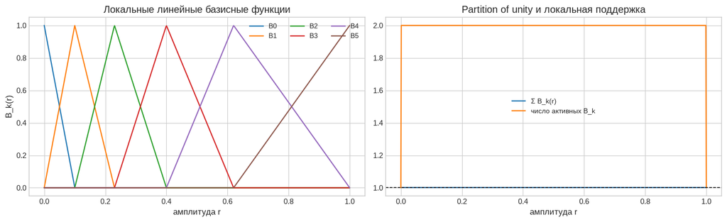

```python
# Иллюстрация локальной поддержки линейного spline basis.
illustration_knots = np.array([0.0, 0.10, 0.23, 0.40, 0.62, 1.0])
illustration_r = np.linspace(0, 1, 700)
left_i, weight_i = spline_coordinates(illustration_r, illustration_knots)
basis_i = np.zeros((illustration_r.size, illustration_knots.size))
rows_i = np.arange(illustration_r.size)
basis_i[rows_i, left_i] = 1 - weight_i
basis_i[rows_i, left_i + 1] += weight_i

fig, axes = plt.subplots(1, 2, figsize=(13.5, 4.2))
for index in range(illustration_knots.size):
    axes[0].plot(illustration_r, basis_i[:, index], label=f"B{index}")
axes[0].set(xlabel="амплитуда r", ylabel="B_k(r)",
            title="Локальные линейные базисные функции")
axes[0].legend(ncols=3)

active_count = np.sum(basis_i > 1e-14, axis=1)
axes[1].plot(illustration_r, basis_i.sum(axis=1), label="Σ B_k(r)")
axes[1].plot(illustration_r, active_count, label="число активных B_k")
axes[1].axhline(1, color="black", ls="--", lw=1)
axes[1].set(xlabel="амплитуда r", title="Partition of unity и локальная поддержка")
axes[1].legend()
assert np.max(np.abs(basis_i.sum(axis=1) - 1.0)) < 1e-14
assert np.max(active_count) <= 2
plt.tight_layout()
plt.show()
```

## 9. Калибровка коэффициентов

Используется Indirect Learning Architecture только как метод калибровки. На train формируется нормированный выход PA

$$ u[n]=\frac{y[n]}{g}, $$

и локальные признаки

$$ \Phi_{n,(m,k)}=u[n-m]B_k(|u[n-m]|). $$

Коэффициенты находятся из выпуклой задачи

$$ \widehat{\mathbf c}=\arg\min_{\mathbf c} \frac{1}{N}\|\Phi\mathbf c-\mathbf x\|_2^2 +\lambda\|\mathbf c\|_2^2. $$

При фиксированных узлах это одна комплексная linear least-squares задача. После fit коэффициенты переносятся в predistorter, а validation начинается с desired $x_{val}$.

### Правило выбора модели

Проверяются две причинные топологии и $K\in\{4,8,12,16,24,32\}$. Выбирается модель с минимальным числом вещественных коэффициентов среди вариантов, находящихся не далее 0.01 dB от лучшего validation NMSE. Это заранее заданный компромисс между качеством и памятью.

```
no DPD: -16.010351 dB
selection rule: smallest model within 0.01 dB of best
topology                        K   NMSE [dB]  real coef   fit [s]
общая текущая амплитуда         4  -11.402039         24    0.1518
общая текущая амплитуда         8  -11.413019         48    0.3823
общая текущая амплитуда        12  -11.583653         72    0.6038
общая текущая амплитуда        16  -11.720803         96    0.8782
общая текущая амплитуда        24  -11.939839        144    1.6488
общая текущая амплитуда        32  -12.111103        192    2.4546
согласованные задержки          4  -16.546080         24    0.1748
согласованные задержки          8  -16.819523         48    0.3536
согласованные задержки         12  -16.968149         72    0.5137
согласованные задержки         16  -17.080311         96    0.8355
согласованные задержки         24  -17.192240        144    1.6485
согласованные задержки         32  -17.198500        192    2.6977
selected: {'topology': 'согласованные задержки', 'branches': ((0, 0), (1, 1), (2, 2)), 'K': 24, 'nmse_db': -17.192240437598432, 'real_coefficients': 144, 'fit_seconds': 1.6484716340000887, 'finite': True, 'max_drive': 0.923164948801733}
```

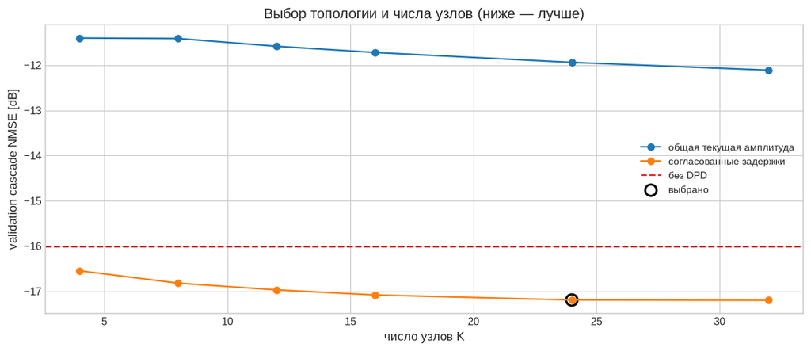

```
branches: ((0, 0), (1, 1), (2, 2)) knots: 24 ridge: 0.0001
coefficients: (3, 24) fit warmup: 2
{'name': 'зафиксированный spline-memory DPD', 'nmse_db': -17.192240437598432, 'rms': 0.40311098016628877, 'peak': 1.0222165981698976, 'papr_db': 8.082366012561241}
improvement over frozen-PA no-DPD: 1.182 dB
```

```python
# Model selection uses train for fit and validation for ranking.
# The smallest K within 0.01 dB of the best validation NMSE is retained.
TOPOLOGIES = {
    "общая текущая амплитуда": ((0, 0), (1, 0), (2, 0)),
    "согласованные задержки": ((0, 0), (1, 1), (2, 2)),
}
K_CANDIDATES = (4, 8, 12, 16, 24, 32)
RIDGE = 1e-4
NMSE_TOLERANCE_DB = 0.01
ila_input = train_y / gain
ideal_val = gain * val_x
no_dpd_nmse_db = pooled_nmse_db(pa_val_hat, ideal_val, CASCADE_WARMUP)
selection_rows = []

for topology_name, candidate_branches in TOPOLOGIES.items():
    for candidate_k in K_CANDIDATES:
        candidate_knots = make_quantile_knots(ila_input, candidate_k)
        started = time.perf_counter()
        candidate_coefficients, candidate_warmup = fit_spline_memory_dpd(
            ila_input, train_x, candidate_knots, candidate_branches, RIDGE
        )
        fit_seconds = time.perf_counter() - started
        candidate_drive = predict_spline_memory(
            val_x, candidate_knots, candidate_branches, candidate_coefficients
        )
        candidate_output = gmp_design(candidate_drive, pa_terms) @ pa_coefficients
        selection_rows.append({
            "topology": topology_name,
            "branches": candidate_branches,
            "K": candidate_k,
            "nmse_db": pooled_nmse_db(candidate_output, ideal_val, CASCADE_WARMUP),
            "real_coefficients": 2 * len(candidate_branches) * candidate_k,
            "fit_seconds": fit_seconds,
            "finite": bool(np.all(np.isfinite(candidate_coefficients))),
            "max_drive": float(np.max(np.abs(candidate_drive))),
        })

best_nmse = min(row["nmse_db"] for row in selection_rows)
eligible = [row for row in selection_rows if row["nmse_db"] <= best_nmse + NMSE_TOLERANCE_DB]
selected = min(eligible, key=lambda row: (row["real_coefficients"], row["nmse_db"]))
branches = selected["branches"]
knot_count = selected["K"]
ridge = RIDGE

print(f"no DPD: {no_dpd_nmse_db:.6f} dB")
print(f"selection rule: smallest model within {NMSE_TOLERANCE_DB:.2f} dB of best")
print(f"{'topology':29s} {'K':>3s} {'NMSE [dB]':>11s} {'real coef':>10s} {'fit [s]':>9s}")
for row in selection_rows:
    print(f"{row['topology']:29s} {row['K']:3d} {row['nmse_db']:11.6f} "
          f"{row['real_coefficients']:10d} {row['fit_seconds']:9.4f}")
print("selected:", selected)

fig, ax = plt.subplots(figsize=(10.5, 4.6))
for topology_name in TOPOLOGIES:
    rows = [row for row in selection_rows if row["topology"] == topology_name]
    ax.plot([row["K"] for row in rows], [row["nmse_db"] for row in rows],
            marker="o", label=topology_name)
ax.axhline(no_dpd_nmse_db, color="tab:red", ls="--", label="без DPD")
ax.scatter([knot_count], [selected["nmse_db"]], s=110, facecolors="none",
           edgecolors="black", linewidths=2, label="выбрано")
ax.set(xlabel="число узлов K", ylabel="validation cascade NMSE [dB]",
       title="Выбор топологии и числа узлов (ниже — лучше)")
ax.legend()
plt.tight_layout()
plt.show()

# Refit exactly the chosen configuration on train; deployment receives val_x.
knots = make_quantile_knots(ila_input, knot_count)
dpd_coefficients, dpd_fit_warmup = fit_spline_memory_dpd(
    ila_input, train_x, knots, branches, ridge
)
predistorted_val = predict_spline_memory(val_x, knots, branches, dpd_coefficients)
cascade_dpd = gmp_design(predistorted_val, pa_terms) @ pa_coefficients
dpd_metrics = metric_row("зафиксированный spline-memory DPD", cascade_dpd, ideal_val, CASCADE_WARMUP)
no_dpd_mse = np.mean(np.abs(pa_val_hat[CASCADE_WARMUP:] - ideal_val[CASCADE_WARMUP:]) ** 2)
dpd_mse = np.mean(np.abs(cascade_dpd[CASCADE_WARMUP:] - ideal_val[CASCADE_WARMUP:]) ** 2)
improvement_db = float(10 * np.log10(no_dpd_mse / dpd_mse))
print("branches:", branches, "knots:", knots.size, "ridge:", ridge)
print("coefficients:", dpd_coefficients.shape, "fit warmup:", dpd_fit_warmup)
print(dpd_metrics)
print(f"improvement over frozen-PA no-DPD: {improvement_db:.3f} dB")
```

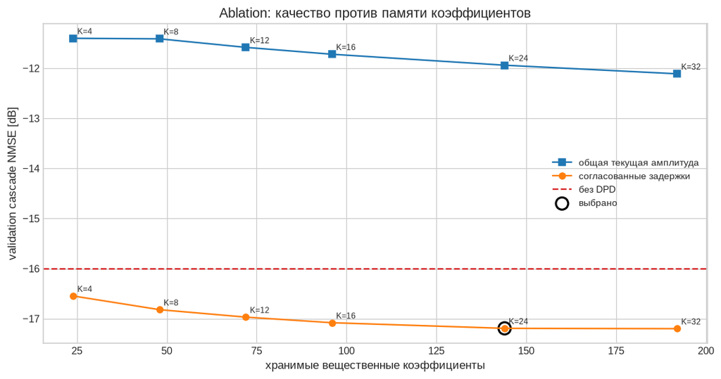

```
Главный отрицательный результат:
топология с общей текущей амплитудой хуже режима без DPD при всех проверенных K.
Выбранная топология: согласованные задержки | K = 24
```

```python
# Дополнительное представление ablation: качество против памяти коэффициентов.
fig, ax = plt.subplots(figsize=(9.8, 5.2))
markers = {"общая текущая амплитуда": "s", "согласованные задержки": "o"}
for topology_name in TOPOLOGIES:
    rows = [row for row in selection_rows if row["topology"] == topology_name]
    ax.plot([row["real_coefficients"] for row in rows],
            [row["nmse_db"] for row in rows], marker=markers[topology_name],
            label=topology_name)
    for row in rows:
        ax.annotate(f"K={row['K']}", (row["real_coefficients"], row["nmse_db"]),
                    xytext=(4, 4), textcoords="offset points", fontsize=8)
ax.axhline(no_dpd_nmse_db, color="tab:red", ls="--", label="без DPD")
ax.scatter(selected["real_coefficients"], selected["nmse_db"], s=140,
           facecolors="none", edgecolors="black", linewidths=2, label="выбрано")
ax.set(xlabel="хранимые вещественные коэффициенты",
       ylabel="validation cascade NMSE [dB]",
       title="Ablation: качество против памяти коэффициентов")
ax.legend()
plt.tight_layout()
plt.show()

print("Главный отрицательный результат:")
print("топология с общей текущей амплитудой хуже режима без DPD при всех проверенных K.")
print("Выбранная топология:", selected["topology"], "| K =", selected["K"])
```

## 9.1. Direct refinement без изменения fast path

### Почему ILA недостаточно

ILA определяет начальный банк $\mathbf c_0$ из обратной задачи

$$\min_{\mathbf c}\|D_{\mathbf c}(y/g)-x\|_2^2,$$

но конечная цель имеет другую функцию потерь:

$$ \mathcal L(\mathbf c)= \|\widehat P(D_{\mathbf c}(x))-gx\|_2^2. $$

Поэтому ILA используется как устойчивое и быстрое начальное приближение, а не как окончательный оптимум каскада.

### Локальная чувствительность каскада

Запишем вещественные и мнимые части 72 комплексных коэффициентов в вектор $\boldsymbol\theta\in\mathbb R^{144}$. В окрестности текущего банка:

$$ \widehat y(\boldsymbol\theta+\Delta\boldsymbol\theta) \approx \widehat y(\boldsymbol\theta)+J\Delta\boldsymbol\theta. $$

Каждый столбец $J$ вычисляется малым конечным изменением соответствующей вещественной или мнимой части коэффициента:

$$ J_k\approx\frac{ \widehat P(D_{\boldsymbol\theta+\varepsilon e_k}(x))- \widehat P(D_{\boldsymbol\theta}(x))}{\varepsilon}. $$

Такой способ не требует менять PA evaluator и соответствует идее безопасного малого probe для будущего physical closed-loop эксперимента.

### Регуляризованное обновление

Для $e=gx-\widehat y$ решается вещественная ridge-задача

$$ \Delta\boldsymbol\theta= \arg\min_{\Delta}\|J\Delta-e\|_2^2+\lambda\|\Delta\|_2^2, $$

после чего

$$\boldsymbol\theta_{new}=\boldsymbol\theta_{old}+\alpha\Delta\boldsymbol\theta.$$

Ridge ограничивает плохо обусловленные направления, а шаг $\alpha$ выбирается на отдельном train-advisor блоке. Jacobian и advisor не пересекаются; validation не используется для коэффициентов, шага или остановки. Число дополнительных итераций зафиксировано заранее. Поскольку меняются только значения LUT, inference formula и operation count остаются прежними.

### Что происходит на практике

ILA даёт быструю начальную настройку, но обучает обратное преобразование усилителя, а не весь каскад. Direct refinement задаёт более прямой вопрос: «как небольшое изменение каждого коэффициента изменит ошибку на выходе PA?».

Матрица $J$, или якобиан, — это просто таблица таких чувствительностей. Ridge-штраф не даёт поправке стать необоснованно большой, а шаг $\alpha$ задаёт, какую долю рассчитанной поправки мы применяем. Всё это выполняется во время калибровки; в рабочем тракте якобиана нет.

```python
# Воспроизводимый replay финального direct-refined банка и его provenance.
DIRECT_MODEL_B64 = """UEsDBC0AAAAAAAAAIQCksZ+q//////////8SABQAc2NoZW1hX3ZlcnNpb24u…=="""
DIRECT_MODEL_SHA256 = "ddba7f70b63de3c9d3f72991f965a67b7f912795f1cea2556108e1a31a8eb222"
DIRECT_REFINEMENT_JSON_B64 = """ewogICJzdGFnZSI6ICJkaXJlY3RfcmVmaW5lbWVudCIsCiAgImNhbGlicmF0…"""
DIRECT_REFINEMENT_JSON_SHA256 = "acd9ebbf2e6ee642f84ab5744668f5164e4e233d45c2bd68f7736e3078d5e1dd"
ITERATIVE_JSON_B64 = """ewogICJzdGFnZSI6ICJpdGVyYXRpdmVfYm91bmRlZF9kaXJlY3RfcmVmaW5l…="""
ITERATIVE_JSON_SHA256 = "22af6417e73effcd2893b0dabfb50fa073e3fa2c76d6d8a053c4d6a3a63fb7fa"

def decode_json_payload(encoded, expected_sha256):
    raw_bytes = base64.b64decode(encoded)
    assert hashlib.sha256(raw_bytes).hexdigest() == expected_sha256
    return json.loads(raw_bytes.decode("utf-8"))

model_bytes = base64.b64decode(DIRECT_MODEL_B64)
assert hashlib.sha256(model_bytes).hexdigest() == DIRECT_MODEL_SHA256
with np.load(io.BytesIO(model_bytes), allow_pickle=False) as frozen_model:
    refined_knots = np.asarray(frozen_model["knots"], dtype=float)
    refined_signal_delays = tuple(int(v) for v in frozen_model["signal_delays"])
    refined_envelope_delays = tuple(int(v) for v in frozen_model["envelope_delays"])
    refined_dpd_coefficients = np.asarray(
        frozen_model["coefficients"], dtype=np.complex128
    )

direct_report = decode_json_payload(
    DIRECT_REFINEMENT_JSON_B64, DIRECT_REFINEMENT_JSON_SHA256
)
iterative_report = decode_json_payload(ITERATIVE_JSON_B64, ITERATIVE_JSON_SHA256)

assert np.allclose(refined_knots, knots)
assert tuple(zip(refined_signal_delays, refined_envelope_delays)) == tuple(branches)
assert refined_dpd_coefficients.shape == dpd_coefficients.shape

predistorted_refined_val = predict_spline_memory(
    val_x, refined_knots, branches, refined_dpd_coefficients
)
cascade_refined = gmp_design(predistorted_refined_val, pa_terms) @ pa_coefficients
refined_metrics = metric_row(
    "iterative direct-refined spline", cascade_refined, ideal_val, CASCADE_WARMUP
)
refined_mse = np.mean(
    np.abs(cascade_refined[CASCADE_WARMUP:] - ideal_val[CASCADE_WARMUP:]) ** 2
)
direct_gain_over_ila_db = dpd_metrics["nmse_db"] - refined_metrics["nmse_db"]
direct_gain_over_no_dpd_db = surrogate_no_dpd["nmse_db"] - refined_metrics["nmse_db"]

# The embedded replay must reproduce the separately generated JSON evidence.
assert abs(refined_metrics["nmse_db"]
           - iterative_report["final_validation"]["nmse_db"]) < 1e-8
assert abs(dpd_metrics["nmse_db"]
           - direct_report["baseline_validation"]["nmse_db"]) < 1e-8

print(f"ILA validation NMSE: {dpd_metrics['nmse_db']:.6f} dB")
print(f"Direct-refined NMSE: {refined_metrics['nmse_db']:.6f} dB")
print(f"Gain over ILA: {direct_gain_over_ila_db:.6f} dB")
print(f"Gain over no DPD: {direct_gain_over_no_dpd_db:.6f} dB")
print("Fast-path topology changed: False")
print("Frozen model SHA-256:", DIRECT_MODEL_SHA256)
```

```
ILA validation NMSE: -17.192240 dB
Direct-refined NMSE: -21.587580 dB
Gain over ILA: 4.395340 dB
Gain over no DPD: 5.577229 dB
Fast-path topology changed: False
Frozen model SHA-256: ddba7f70b63de3c9d3f72991f965a67b7f912795f1cea2556108e1a31a8eb222
```

## 10. Основной результат на validation

Здесь сравниваются не две разные DPD-архитектуры, а последовательные состояния **одной spline-memory модели**:

1. PA без DPD;
2. наш spline-memory baseline после начальной ILA-калибровки;
3. тот же baseline после direct refinement его 72 комплексных коэффициентов.

Число ветвей, узлов, задержек и операций в пунктах 2 и 3 одинаково. Поэтому разность качества показывает эффект способа калибровки, а не выигрыш от более крупной модели. Ось NMSE сфокусирована на рабочем диапазоне dB; над каждым столбцом приведено точное значение.

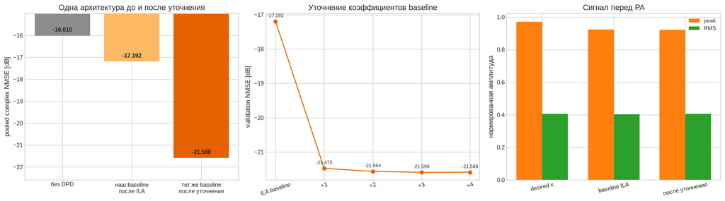

```
Выигрыш уточнения относительно ILA-baseline: 4.395340 dB
Выигрыш уточнённого baseline относительно режима без DPD: 5.577229 dB
Baseline после ILA: {'rms': 0.402828007934089, 'peak': 0.923164948801733, 'papr_db': 7.20319295870158}
Тот же baseline после уточнения: {'rms': 0.40488424160330644, 'peak': 0.920485351521888, 'papr_db': 7.133720151196402}
```

```python
# NMSE, сходимость уточнения и уровни сигнала перед PA.
NO_DPD_COLOR = "0.55"
BASELINE_COLOR = "#FDB863"
REFINED_COLOR = "#E66101"

result_names = ["без DPD", "наш baseline\nпосле ILA", "тот же baseline\nпосле уточнения"]
result_nmse = [surrogate_no_dpd["nmse_db"], dpd_metrics["nmse_db"],
               refined_metrics["nmse_db"]]

history = [dpd_metrics["nmse_db"],
           iterative_report["one_update_validation"]["nmse_db"]]
history.extend(
    row["validation_diagnostic_not_used_for_stopping"]["nmse_db"]
    for row in iterative_report["schedules"]["predeclared_A"]["updates"]
)
history_labels = ["ILA baseline", "+1", "+2", "+3", "+4"]

fig, axes = plt.subplots(1, 3, figsize=(17, 4.8))
bars = axes[0].bar(result_names, result_nmse,
                   color=[NO_DPD_COLOR, BASELINE_COLOR, REFINED_COLOR])
axes[0].set(ylabel="pooled complex NMSE [dB]",
            title="Одна архитектура до и после уточнения")
axes[0].set_ylim(min(result_nmse) - 1.0, max(result_nmse) + 1.0)
for bar, value in zip(bars, result_nmse):
    axes[0].text(bar.get_x() + bar.get_width()/2, value + 0.18,
                 f"{value:.3f}", ha="center", weight="bold")

axes[1].plot(np.arange(len(history)), history, "o-", color=REFINED_COLOR)
axes[1].set_xticks(np.arange(len(history)), history_labels, rotation=18)
axes[1].set(ylabel="validation NMSE [dB]",
            title="Уточнение коэффициентов baseline")
for index, value in enumerate(history):
    axes[1].annotate(f"{value:.3f}", (index, value), xytext=(0, 7),
                     textcoords="offset points", ha="center", fontsize=8)

drive_rows = {
    "desired x": summary(val_x[CASCADE_WARMUP:]),
    "baseline ILA": summary(predistorted_val[CASCADE_WARMUP:]),
    "после уточнения": summary(predistorted_refined_val[CASCADE_WARMUP:]),
}
drive_names = list(drive_rows)
positions = np.arange(len(drive_names))
axes[2].bar(positions - 0.18,
            [drive_rows[name]["peak"] for name in drive_names], width=0.36,
            label="peak", color="tab:orange")
axes[2].bar(positions + 0.18,
            [drive_rows[name]["rms"] for name in drive_names], width=0.36,
            label="RMS", color="tab:green")
axes[2].set_xticks(positions, drive_names, rotation=12)
axes[2].set(title="Сигнал перед PA", ylabel="нормированная амплитуда")
axes[2].legend()
plt.tight_layout()
plt.show()

print(f"Выигрыш уточнения относительно ILA-baseline: {direct_gain_over_ila_db:.6f} dB")
print(f"Выигрыш уточнённого baseline относительно режима без DPD: {direct_gain_over_no_dpd_db:.6f} dB")
print("Baseline после ILA:", drive_rows["baseline ILA"])
print("Тот же baseline после уточнения:", drive_rows["после уточнения"])
```

### 10.1. AM/AM и AM/PM до и после коррекции

Этот рисунок наглядно показывает два типа искажений. **AM/AM** отвечает на вопрос, как меняется выходная амплитуда при росте $|x|$. **AM/PM** показывает ошибку фазы:

$$ \Delta\varphi[n]=\arg\!\left(\widehat y[n](g x[n])^*\right). $$

Верхний ряд — PA evaluator без DPD. Нижний ряд — наш spline-memory DPD: жёлтым показана начальная ILA-калибровка, оранжевым — та же модель после direct refinement. Чёрная линия соответствует идеальному ответу. Точки не являются отдельными I/Q-моделями: они рассчитаны из единого комплексного сигнала.

У очень слабых отсчётов фаза плохо определена, поэтому в AM/PM не показаны точки ниже 2% максимальной амплитуды. Полоса 10–90% показывает разброс большинства отсчётов, а не доверительный интервал.

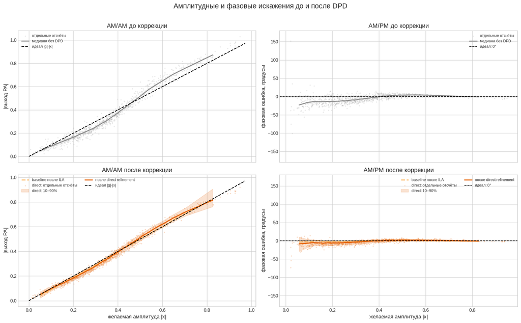

```
Оранжевый результат — та же spline-memory архитектура после direct refinement.
Измеренный validation y не подавался на вход DPD.
```

```python
# AM/AM and AM/PM before and after correction on the same validation record.
radius = np.abs(val_x)
ideal_amplitude = np.abs(ideal_val)
sample_indices = np.arange(CASCADE_WARMUP, val_x.size, 25)
r_grid = np.linspace(0, radius.max(), 300)


def phase_error_degrees(output, reference):
    """Wrapped phase difference between complex output and desired reference."""
    return np.degrees(np.angle(output * np.conj(reference)))


phase_mask = ideal_amplitude > 0.02 * np.max(ideal_amplitude)
phase_indices = np.flatnonzero(phase_mask)[::25]
phase_no_dpd = phase_error_degrees(pa_val_hat, ideal_val)
phase_ila = phase_error_degrees(cascade_dpd, ideal_val)
phase_direct = phase_error_degrees(cascade_refined, ideal_val)

no_dpd_am = quantile_binned_statistics(radius, np.abs(pa_val_hat), 32)
ila_am = quantile_binned_statistics(radius, np.abs(cascade_dpd), 32)
direct_am = quantile_binned_statistics(radius, np.abs(cascade_refined), 32)
no_dpd_pm = quantile_binned_statistics(radius[phase_mask], phase_no_dpd[phase_mask], 32)
ila_pm = quantile_binned_statistics(radius[phase_mask], phase_ila[phase_mask], 32)
direct_pm = quantile_binned_statistics(radius[phase_mask], phase_direct[phase_mask], 32)

fig, axes = plt.subplots(2, 2, figsize=(15.5, 9.4), sharex="col")

axes[0, 0].scatter(radius[sample_indices], np.abs(pa_val_hat)[sample_indices],
                   s=3, alpha=0.12, color=NO_DPD_COLOR, label="отдельные отсчёты")
axes[0, 0].plot(no_dpd_am["center"], no_dpd_am["median"],
                color=NO_DPD_COLOR, lw=2.0, label="медиана без DPD")
axes[0, 0].plot(r_grid, abs(gain) * r_grid, "k--", lw=1.5, label="идеал |g|·|x|")
axes[0, 0].set(ylabel="|выход PA|", title="AM/AM до коррекции")
axes[0, 0].legend(fontsize=8)

axes[0, 1].scatter(radius[phase_indices], phase_no_dpd[phase_indices],
                   s=3, alpha=0.12, color=NO_DPD_COLOR, label="отдельные отсчёты")
axes[0, 1].plot(no_dpd_pm["center"], no_dpd_pm["median"],
                color=NO_DPD_COLOR, lw=2.0, label="медиана без DPD")
axes[0, 1].axhline(0.0, color="black", ls="--", lw=1.2, label="идеал: 0°")
axes[0, 1].set(ylabel="фазовая ошибка, градусы", title="AM/PM до коррекции", ylim=(-180, 180))
axes[0, 1].legend(fontsize=8)

axes[1, 0].plot(ila_am["center"], ila_am["median"],
                color=BASELINE_COLOR, ls="--", lw=2.2, label="baseline после ILA")
axes[1, 0].scatter(radius[sample_indices], np.abs(cascade_refined)[sample_indices],
                   s=3, alpha=0.15, color=REFINED_COLOR, label="direct: отдельные отсчёты")
axes[1, 0].fill_between(direct_am["center"], direct_am["q10"], direct_am["q90"],
                        color=REFINED_COLOR, alpha=0.18, label="direct: 10–90%")
axes[1, 0].plot(direct_am["center"], direct_am["median"],
                color=REFINED_COLOR, lw=2.2, label="после direct refinement")
axes[1, 0].plot(r_grid, abs(gain) * r_grid, "k--", lw=1.5, label="идеал |g|·|x|")
axes[1, 0].set(xlabel="желаемая амплитуда |x|", ylabel="|выход PA|",
               title="AM/AM после коррекции")
axes[1, 0].legend(fontsize=8, ncol=2)

axes[1, 1].plot(ila_pm["center"], ila_pm["median"],
                color=BASELINE_COLOR, ls="--", lw=2.2, label="baseline после ILA")
axes[1, 1].scatter(radius[phase_indices], phase_direct[phase_indices],
                   s=3, alpha=0.15, color=REFINED_COLOR, label="direct: отдельные отсчёты")
axes[1, 1].fill_between(direct_pm["center"], direct_pm["q10"], direct_pm["q90"],
                        color=REFINED_COLOR, alpha=0.18, label="direct: 10–90%")
axes[1, 1].plot(direct_pm["center"], direct_pm["median"],
                color=REFINED_COLOR, lw=2.2, label="после direct refinement")
axes[1, 1].axhline(0.0, color="black", ls="--", lw=1.2, label="идеал: 0°")
axes[1, 1].set(xlabel="желаемая амплитуда |x|", ylabel="фазовая ошибка, градусы",
               title="AM/PM после коррекции", ylim=(-180, 180))
axes[1, 1].legend(fontsize=8, ncol=2)

fig.suptitle("Амплитудные и фазовые искажения до и после DPD", fontsize=15, y=1.01)
plt.tight_layout()
plt.show()

print("Оранжевый результат — та же spline-memory архитектура после direct refinement.")
print("Измеренный validation y не подавался на вход DPD.")
```

### 10.2 Коэффициенты одной модели до и после улучшения

На каждом графике одновременно показана **одна spline-memory архитектура** в двух состояниях:

- жёлтая пунктирная линия и круглые узлы — исходный baseline после ILA;
- оранжевая линия и квадратные узлы — тот же baseline после direct refinement.

Одинаковые оси позволяют непосредственно увидеть изменение каждого комплексного коэффициента. Точки являются узлами LUT, линии — линейной интерполяцией рабочего тракта. Под рисунком приведены численные значения representative knots; полная таблица всех 24 узлов раскрывается по нажатию.

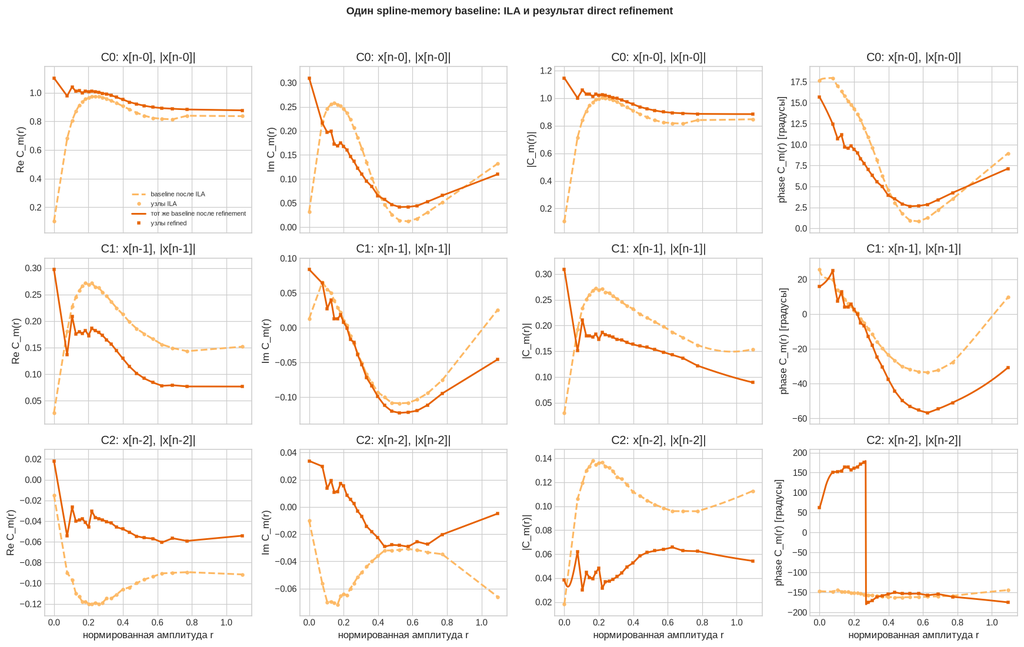

Численные значения representative knots: ILA и refined

| k | r | C0 ILA | C0 refined | C1 ILA | C1 refined | C2 ILA | C2 refined |
| --- | --- | --- | --- | --- | --- | --- | --- |
| 0 | 0.000000 | +0.101324+0.032273j | +1.103434+0.310031j | +0.027251+0.013114j | +0.297234+0.084019j | -0.015058-0.009982j | +0.018152+0.033852j |
| 4 | 0.146192 | +0.912266+0.258281j | +1.013815+0.172997j | +0.257324+0.038828j | +0.179868+0.012846j | -0.112977-0.070568j | -0.039105+0.010950j |
| 8 | 0.219585 | +0.974664+0.237130j | +1.010468+0.160544j | +0.271533+0.003542j | +0.186183-0.000287j | -0.120392-0.064740j | -0.030290+0.008515j |
| 12 | 0.305986 | +0.959300+0.163156j | +0.992244+0.109730j | +0.247062-0.050490j | +0.164606-0.053056j | -0.114517-0.047920j | -0.040592-0.006946j |
| 15 | 0.398598 | +0.907063+0.072437j | +0.953455+0.065543j | +0.213211-0.092697j | +0.129831-0.099177j | -0.105872-0.036095j | -0.047542-0.022515j |
| 19 | 0.573915 | +0.823970+0.011893j | +0.898813+0.041968j | +0.166222-0.108349j | +0.084407-0.121874j | -0.093572-0.030821j | -0.056841-0.029171j |
| 23 | 1.094298 | +0.836562+0.132076j | +0.877142+0.109895j | +0.151833+0.026005j | +0.076807-0.045563j | -0.091476-0.066010j | -0.054086-0.004842j |

**Показать точные значения всех 24 узлов**

| k | r | C0 ILA | C0 refined | C1 ILA | C1 refined | C2 ILA | C2 refined |
| --- | --- | --- | --- | --- | --- | --- | --- |
| 0 | 0.000000 | +0.101324+0.032273j | +1.103434+0.310031j | +0.027251+0.013114j | +0.297234+0.084019j | -0.015058-0.009982j | +0.018152+0.033852j |
| 1 | 0.076430 | +0.680344+0.220614j | +0.977415+0.216228j | +0.181232+0.065724j | +0.137087+0.064198j | -0.089775-0.056328j | -0.054363+0.029876j |
| 2 | 0.105179 | +0.805928+0.246433j | +1.041359+0.197063j | +0.227383+0.055553j | +0.209213+0.027703j | -0.096748-0.070016j | -0.026566+0.013659j |
| 3 | 0.126981 | +0.869991+0.255419j | +1.009062+0.199089j | +0.245333+0.050565j | +0.175754+0.040403j | -0.109687-0.069420j | -0.040111+0.019468j |
| 4 | 0.146192 | +0.912266+0.258281j | +1.013815+0.172997j | +0.257324+0.038828j | +0.179868+0.012846j | -0.112977-0.070568j | -0.039105+0.010950j |
| 5 | 0.165009 | +0.935123+0.254521j | +0.998514+0.168483j | +0.266119+0.029003j | +0.176516+0.012959j | -0.117920-0.071562j | -0.037794+0.011377j |
| 6 | 0.182725 | +0.955804+0.252592j | +1.012479+0.175502j | +0.271694+0.021973j | +0.182613+0.018424j | -0.117707-0.065465j | -0.041238+0.017332j |
| 7 | 0.200658 | +0.963959+0.245919j | +1.007236+0.167440j | +0.268753+0.010212j | +0.172747+0.007729j | -0.119842-0.064135j | -0.045817+0.015330j |
| 8 | 0.219585 | +0.974664+0.237130j | +1.010468+0.160544j | +0.271533+0.003542j | +0.186183-0.000287j | -0.120392-0.064740j | -0.030290+0.008515j |
| 9 | 0.238748 | +0.972686+0.223749j | +1.008372+0.147235j | +0.264445-0.011814j | +0.181786-0.016600j | -0.118780-0.059924j | -0.036361+0.005689j |
| 10 | 0.259783 | +0.974583+0.206214j | +1.004468+0.136540j | +0.262738-0.022656j | +0.178716-0.021260j | -0.119911-0.056004j | -0.037477+0.002401j |
| 11 | 0.281892 | +0.967240+0.186134j | +0.995705+0.122520j | +0.254480-0.037297j | +0.172895-0.039161j | -0.118823-0.051410j | -0.038804-0.003090j |
| 12 | 0.305986 | +0.959300+0.163156j | +0.992244+0.109730j | +0.247062-0.050490j | +0.164606-0.053056j | -0.114517-0.047920j | -0.040592-0.006946j |
| 13 | 0.333313 | +0.943661+0.135206j | +0.981886+0.095367j | +0.236339-0.067091j | +0.156470-0.071963j | -0.114626-0.043890j | -0.041963-0.014174j |
| 14 | 0.364041 | +0.927645+0.102079j | +0.968601+0.084425j | +0.224465-0.079704j | +0.144050-0.084090j | -0.110883-0.039927j | -0.045942-0.018282j |
| 15 | 0.398598 | +0.907063+0.072437j | +0.953455+0.065543j | +0.213211-0.092697j | +0.129831-0.099177j | -0.105872-0.036095j | -0.047542-0.022515j |
| 16 | 0.437280 | +0.884117+0.047065j | +0.934931+0.057355j | +0.198424-0.100194j | +0.114728-0.111956j | -0.104055-0.032014j | -0.050638-0.029124j |
| 17 | 0.479329 | +0.860687+0.026381j | +0.921270+0.046870j | +0.185841-0.108291j | +0.101876-0.120265j | -0.099898-0.031928j | -0.054616-0.027869j |
| 18 | 0.524341 | +0.839774+0.013884j | +0.909022+0.041844j | +0.176004-0.108846j | +0.091946-0.122639j | -0.096429-0.031514j | -0.056121-0.028116j |
| 19 | 0.573915 | +0.823970+0.011893j | +0.898813+0.041968j | +0.166222-0.108349j | +0.084407-0.121874j | -0.093572-0.030821j | -0.056841-0.029171j |
| 20 | 0.627143 | +0.817676+0.017773j | +0.892479+0.044407j | +0.155919-0.103324j | +0.078181-0.119457j | -0.090491-0.031670j | -0.060555-0.025494j |
| 21 | 0.687930 | +0.814113+0.031085j | +0.888132+0.052984j | +0.149330-0.094238j | +0.079354-0.111260j | -0.089925-0.033268j | -0.056542-0.027467j |
| 22 | 0.772030 | +0.839262+0.051228j | +0.883263+0.065613j | +0.143402-0.075540j | +0.076948-0.094747j | -0.089281-0.034685j | -0.059121-0.020250j |
| 23 | 1.094298 | +0.836562+0.132076j | +0.877142+0.109895j | +0.151833+0.026005j | +0.076807-0.045563j | -0.091476-0.066010j | -0.054086-0.004842j |

```
Относительное изменение одного и того же банка: 0.292415
Topology, K и стоимость inference не изменились.
```

```python
# Два банка одной архитектуры: ILA-начало и тот же baseline после уточнения.
from html import escape
from IPython.display import HTML, display

dense_radius = np.linspace(knots[0], knots[-1], 500)
dense_left, dense_weight = spline_coordinates(dense_radius, knots)
component_names = ("Re C_m(r)", "Im C_m(r)", "|C_m(r)|",
                   "phase C_m(r) [градусы]")


def coefficient_components(coefficients):
    """Return dense real, imaginary, magnitude and phase curves by branch."""
    result = []
    for branch_coefficients in coefficients:
        dense = (branch_coefficients[dense_left]
                 + dense_weight * (branch_coefficients[dense_left + 1]
                                   - branch_coefficients[dense_left]))
        result.append((dense.real, dense.imag, np.abs(dense),
                       np.degrees(np.angle(dense))))
    return result


ila_components = coefficient_components(dpd_coefficients)
refined_components = coefficient_components(refined_dpd_coefficients)

# Одинаковые пределы соответствующих осей для честного сравнения двух банков.
component_limits = {}
for branch_index in range(len(branches)):
    for column in range(4):
        combined = np.concatenate((ila_components[branch_index][column],
                                   refined_components[branch_index][column]))
        lower, upper = float(np.min(combined)), float(np.max(combined))
        margin = 0.08 * max(upper - lower, 1e-3)
        component_limits[branch_index, column] = (lower - margin, upper + margin)



def plot_combined_coefficient_banks():
    """Overlay ILA and refined control points on identical axes."""
    fig, axes = plt.subplots(3, 4, figsize=(16, 10), sharex=True)
    for branch_index, (signal_delay, envelope_delay) in enumerate(branches):
        ila_knots = dpd_coefficients[branch_index]
        refined_knots = refined_dpd_coefficients[branch_index]
        ila_knot_values = (
            ila_knots.real,
            ila_knots.imag,
            np.abs(ila_knots),
            np.degrees(np.angle(ila_knots)),
        )
        refined_knot_values = (
            refined_knots.real,
            refined_knots.imag,
            np.abs(refined_knots),
            np.degrees(np.angle(refined_knots)),
        )
        for column, ylabel in enumerate(component_names):
            axis = axes[branch_index, column]
            axis.plot(
                dense_radius,
                ila_components[branch_index][column],
                color=BASELINE_COLOR,
                ls="--",
                lw=2.0,
                label="baseline после ILA" if branch_index == column == 0 else None,
            )
            axis.plot(
                knots,
                ila_knot_values[column],
                "o",
                ms=3.2,
                color=BASELINE_COLOR,
                alpha=0.90,
                label="узлы ILA" if branch_index == column == 0 else None,
            )
            axis.plot(
                dense_radius,
                refined_components[branch_index][column],
                color=REFINED_COLOR,
                lw=1.9,
                label="тот же baseline после refinement"
                if branch_index == column == 0 else None,
            )
            axis.plot(
                knots,
                refined_knot_values[column],
                "s",
                ms=3.0,
                color=REFINED_COLOR,
                alpha=0.90,
                label="узлы refined" if branch_index == column == 0 else None,
            )
            axis.set_ylim(*component_limits[branch_index, column])
            axis.set_ylabel(ylabel)
            axis.set_title(
                f"C{branch_index}: x[n-{signal_delay}], |x[n-{envelope_delay}]|"
            )
            if branch_index == len(branches) - 1:
                axis.set_xlabel("нормированная амплитуда r")
    axes[0, 0].legend(fontsize=7.5)
    fig.suptitle(
        "Один spline-memory baseline: ILA и результат direct refinement",
        y=0.995,
        weight="bold",
    )
    plt.tight_layout(rect=(0, 0, 1, 0.97))
    plt.show()


plot_combined_coefficient_banks()


def format_complex(value):
    """Format one complex control point with explicit real and imaginary parts."""
    return f"{value.real:+.6f}{value.imag:+.6f}j"


def coefficient_table_html(indices, title, opened=False):
    """Build a compact exact-value table for selected or all spline knots."""
    rows = []
    for knot_index in indices:
        cells = [str(knot_index), f"{knots[knot_index]:.6f}"]
        for branch_index in range(len(branches)):
            cells.extend((
                format_complex(dpd_coefficients[branch_index, knot_index]),
                format_complex(refined_dpd_coefficients[branch_index, knot_index]),
            ))
        rows.append("<tr>" + "".join(f"<td>{escape(value)}</td>" for value in cells) + "</tr>")
    headers = ["k", "r"]
    for branch_index in range(len(branches)):
        headers.extend((f"C{branch_index} ILA", f"C{branch_index} refined"))
    table = (
        "<table style='border-collapse:collapse;font-family:monospace;font-size:12px'>"
        "<thead><tr>" + "".join(
            f"<th style='padding:4px 8px;border:1px solid #bbb'>{escape(header)}</th>"
            for header in headers
        ) + "</tr></thead><tbody>" + "".join(rows) + "</tbody></table>"
    )
    if opened:
        return f"<h4>{escape(title)}</h4>{table}"
    return f"<details><summary><b>{escape(title)}</b></summary>{table}</details>"


representative_indices = np.unique(
    np.round(np.linspace(0, knot_count - 1, 7)).astype(int)
)
display(HTML(coefficient_table_html(
    representative_indices,
    "Численные значения representative knots: ILA и refined",
    opened=True,
)))
display(HTML(coefficient_table_html(
    np.arange(knot_count),
    "Показать точные значения всех 24 узлов",
    opened=False,
)))

coefficient_relative_change = float(
    np.linalg.norm(refined_dpd_coefficients - dpd_coefficients)
    / np.linalg.norm(dpd_coefficients)
)
print(f"Относительное изменение одного и того же банка: {coefficient_relative_change:.6f}")
print("Topology, K и стоимость inference не изменились.")
```

### 10.3 Разложение одного отсчёта

Следующий рисунок делает работу трёх ветвей наблюдаемой. Для выбранного $n$ вычисляются

$$ u_m[n]=x[n-m]C_m(|x[n-m]|),\qquad z[n]=u_0[n]+u_1[n]+u_2[n]. $$

Векторы на комплексной плоскости складываются последовательно.

```
n = 148
u0: r=0.238663, C0(r)=1.008381+0.147294j, u0=0.002723-0.243202j
u1: r=0.297460, C1(r)=0.167539-0.048139j, u1=0.048379-0.018659j
u2: r=0.520994, C2(r)=-0.056009-0.028098j, u2=-0.023702-0.022450j
z[n] = u0+u1+u2 = 0.027400-0.284311j
```

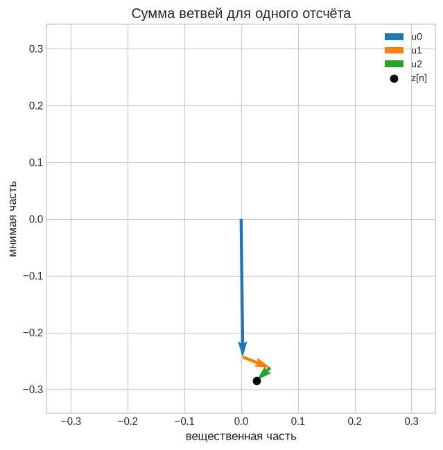

```python
# Один отсчёт финального direct-refined DPD: разложение z[n] на три комплексных вклада.
example_n = CASCADE_WARMUP + 137
contributions = []
example_values = []
for branch_index, (signal_delay, envelope_delay) in enumerate(branches):
    radius = abs(val_x[example_n - envelope_delay])
    left, weight = spline_coordinates(np.array([radius]), knots)
    c_value = (refined_dpd_coefficients[branch_index, left[0]]
               + weight[0] * (refined_dpd_coefficients[branch_index, left[0] + 1]
                              - refined_dpd_coefficients[branch_index, left[0]]))
    contribution = val_x[example_n - signal_delay] * c_value
    contributions.append(contribution)
    example_values.append((radius, c_value))
z_example = sum(contributions)
assert abs(z_example - predistorted_refined_val[example_n]) < 1e-12

print(f"n = {example_n}")
for index, ((radius, c_value), contribution) in enumerate(zip(example_values, contributions)):
    print(f"u{index}: r={radius:.6f}, C{index}(r)={c_value:.6f}, u{index}={contribution:.6f}")
print(f"z[n] = u0+u1+u2 = {z_example:.6f}")

fig, ax = plt.subplots(figsize=(6.4, 6.0))
origin = 0j
for index, contribution in enumerate(contributions):
    ax.quiver(origin.real, origin.imag, contribution.real, contribution.imag,
              angles="xy", scale_units="xy", scale=1, width=0.008,
              color=f"C{index}", label=f"u{index}")
    origin += contribution
ax.scatter([z_example.real], [z_example.imag], color="black", s=45, label="z[n]")
extent = 1.2 * max(abs(z_example), *(abs(value) for value in contributions), 1e-3)
ax.set(xlim=(-extent, extent), ylim=(-extent, extent), xlabel="вещественная часть",
       ylabel="мнимая часть", title="Сумма ветвей для одного отсчёта")
ax.set_aspect("equal", adjustable="box")
ax.legend()
plt.tight_layout()
plt.show()
```

### 10.4 Фрагмент во времени

Показан один и тот же 600-sample интервал. Верхняя панель сравнивает выход каскада с $gx$; нижняя показывает мгновенный модуль комплексной ошибки и локальный RMS. Толстая RMS-линия нужна, потому что знакопеременная вещественная часть ошибки визуально скрывает её мощность.

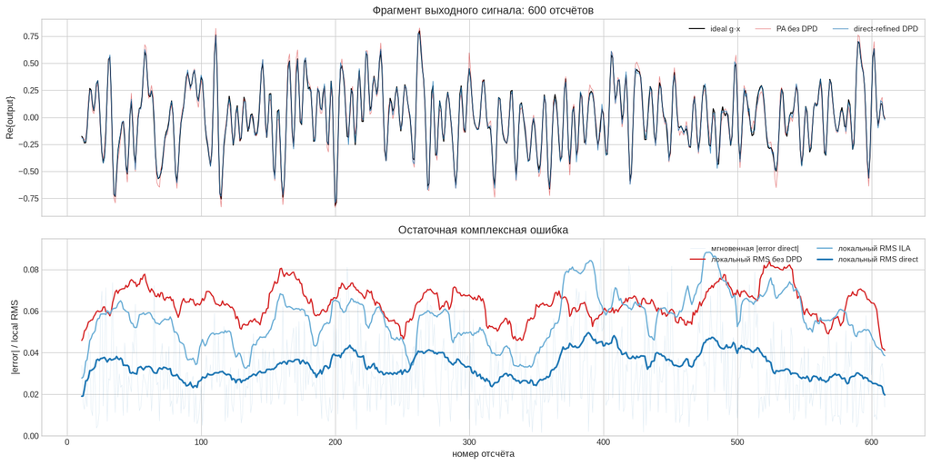

```python
# 600 отсчётов: финальный direct-refined каскад и локальная ошибка.
fragment_length = 600
window = slice(CASCADE_WARMUP, CASCADE_WARMUP + fragment_length)
sample_axis = np.arange(fragment_length) + CASCADE_WARMUP
fig, axes = plt.subplots(2, 1, figsize=(15.5, 7.8), sharex=True)
axes[0].plot(sample_axis, ideal_val[window].real, color="black", lw=1.15,
             label="ideal g·x")
axes[0].plot(sample_axis, pa_val_hat[window].real, color="tab:red",
             alpha=0.55, lw=0.7, label="PA без DPD")
axes[0].plot(sample_axis, cascade_refined[window].real, color="tab:blue",
             alpha=0.82, lw=0.8, label="direct-refined DPD")
axes[0].set_ylabel("Re{output}")
axes[0].set_title("Фрагмент выходного сигнала: 600 отсчётов")
axes[0].legend(loc="upper right", ncols=3)

error_no_dpd = (pa_val_hat - ideal_val)[window]
error_ila = (cascade_dpd - ideal_val)[window]
error_direct = (cascade_refined - ideal_val)[window]

def local_rms(signal: np.ndarray, width=25) -> np.ndarray:
    kernel = np.ones(width, dtype=float) / width
    return np.sqrt(np.convolve(np.abs(signal) ** 2, kernel, mode="same"))

axes[1].plot(sample_axis, np.abs(error_direct), color="tab:blue",
             lw=0.5, alpha=0.15, label="мгновенная |error direct|")
axes[1].plot(sample_axis, local_rms(error_no_dpd), color="tab:red", lw=1.5,
             label="локальный RMS без DPD")
axes[1].plot(sample_axis, local_rms(error_ila), color="#6BAED6", lw=1.5,
             label="локальный RMS ILA")
axes[1].plot(sample_axis, local_rms(error_direct), color="tab:blue", lw=2.0,
             label="локальный RMS direct")
axes[1].set(xlabel="номер отсчёта", ylabel="|error| / local RMS",
            title="Остаточная комплексная ошибка")
axes[1].set_ylim(bottom=0)
axes[1].legend(loc="upper right", ncols=2)
plt.tight_layout()
plt.show()
```

### 10.5 Устойчивость результата по временным сегментам

Pooled NMSE может скрыть локальное ухудшение. Поэтому validation дополнительно делится на восемь последовательных сегментов без перемешивания. Это диагностическая проверка, а не восемь независимых экспериментов.

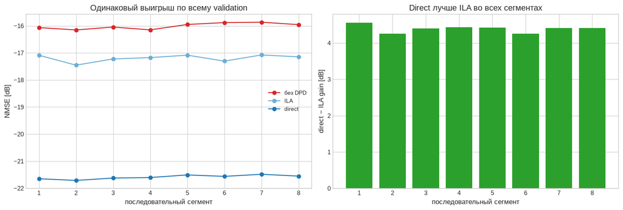

```
Direct gain over ILA by segment [dB]: [4.5608 4.2577 4.3999 4.4304 4.4238 4.258  4.407  4.4071]
Improved segments: 8 / 8
```

```python
# Segment-wise устойчивость ILA и direct refinement.
segment_count = 8
indices = np.arange(CASCADE_WARMUP, val_x.size)
segments = np.array_split(indices, segment_count)
segment_no = np.asarray([
    pooled_nmse_db(pa_val_hat[s], ideal_val[s]) for s in segments
])
segment_ila = np.asarray([
    pooled_nmse_db(cascade_dpd[s], ideal_val[s]) for s in segments
])
segment_direct = np.asarray([
    pooled_nmse_db(cascade_refined[s], ideal_val[s]) for s in segments
])
segment_gain_no_to_direct = segment_no - segment_direct
segment_gain_ila_to_direct = segment_ila - segment_direct

fig, axes = plt.subplots(1, 2, figsize=(14, 4.8))
x_segments = np.arange(1, segment_count + 1)
axes[0].plot(x_segments, segment_no, "o-", color="tab:red", label="без DPD")
axes[0].plot(x_segments, segment_ila, "o-", color="#6BAED6", label="ILA")
axes[0].plot(x_segments, segment_direct, "o-", color="tab:blue", label="direct")
axes[0].set(xlabel="последовательный сегмент", ylabel="NMSE [dB]",
            title="Одинаковый выигрыш по всему validation")
axes[0].legend()
axes[1].bar(x_segments, segment_gain_ila_to_direct, color="tab:green")
axes[1].axhline(0, color="black", lw=0.8)
axes[1].set(xlabel="последовательный сегмент", ylabel="direct − ILA gain [dB]",
            title="Direct лучше ILA во всех сегментах")
plt.tight_layout()
plt.show()

print("Direct gain over ILA by segment [dB]:",
      np.round(segment_gain_ila_to_direct, 4))
print("Improved segments:", int(np.sum(segment_gain_ila_to_direct > 0)), "/", segment_count)
```

### 10.6 Амплитудный запас и PAPR

Линеаризация не должна достигаться неограниченным ростом drive. Помимо peak и RMS полезно сравнить эмпирическую CCDF амплитуды desired и predistorted сигналов.

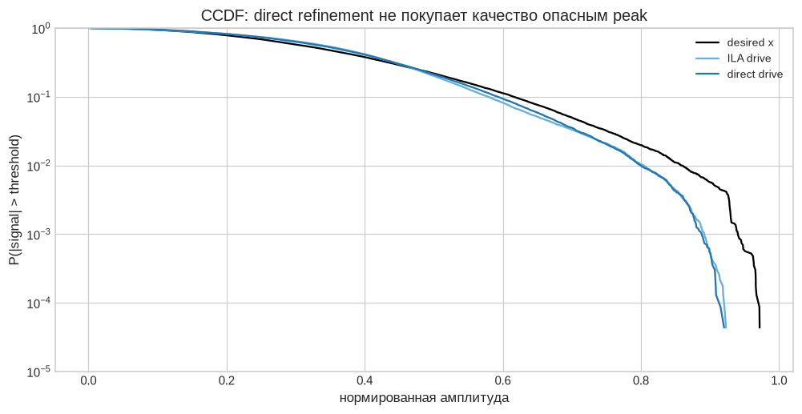

```
desired PAPR: 7.6172 dB
ILA PAPR:     7.2032 dB
direct PAPR:  7.1337 dB
maximum |z_direct|: 0.920485
```

```python
def empirical_ccdf(values: np.ndarray):
    ordered = np.sort(np.asarray(values, dtype=float))
    exceedance = (ordered.size - np.arange(ordered.size)) / ordered.size
    return ordered, exceedance

fig, ax = plt.subplots(figsize=(9.2, 4.8))
for label, signal, color in [
    ("desired x", val_x[CASCADE_WARMUP:], "black"),
    ("ILA drive", predistorted_val[CASCADE_WARMUP:], "#6BAED6"),
    ("direct drive", predistorted_refined_val[CASCADE_WARMUP:], "tab:blue"),
]:
    amplitude, probability = empirical_ccdf(np.abs(signal))
    ax.semilogy(amplitude, probability, color=color, label=label)
ax.set(xlabel="нормированная амплитуда", ylabel="P(|signal| > threshold)",
       title="CCDF: direct refinement не покупает качество опасным peak",
       ylim=(1e-5, 1.0))
ax.legend()
plt.tight_layout()
plt.show()

print(f"desired PAPR: {summary(val_x[CASCADE_WARMUP:])['papr_db']:.4f} dB")
print(f"ILA PAPR:     {summary(predistorted_val[CASCADE_WARMUP:])['papr_db']:.4f} dB")
print(f"direct PAPR:  {summary(predistorted_refined_val[CASCADE_WARMUP:])['papr_db']:.4f} dB")
print(f"maximum |z_direct|: {np.max(np.abs(predistorted_refined_val)):.6f}")
```

## 11. Спектральная диагностика

PSD оценивается методом Welch: Hann window, `N=2048`, overlap `1536`, затем выполняется небольшое сглаживание **линейной мощности** только для читаемости рисунка.

Для BlackBox неизвестны частота дискретизации и официальные границы основной/соседних полос. Поэтому ось показывается в циклах на отсчёт, а произвольный ACLR не придумывается. Чёрный пунктир — реальный спектр $gx$, который не обязан быть плоским.

### Как читать спектр

Центральная широкая часть — полезный сигнал. «Плечи» слева и справа появляются из-за нелинейности PA. Чем ближе крива DPD к чёрному идеалу вне центральной области, тем меньше спектральное разрастание. График ниже вынесен отдельно, чтобы различия не сжимались в узкой панели.

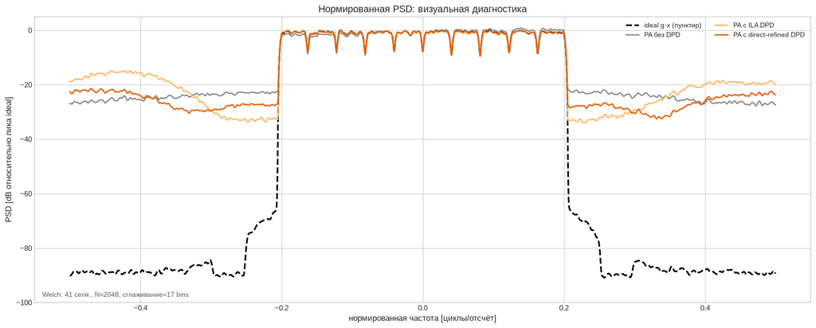

```python
def welch_complex(signal: np.ndarray, nperseg=2048, noverlap=1536):
    """Estimate a normalized-frequency Welch PSD for a complex vector."""
    signal = np.asarray(signal, dtype=np.complex128)
    step = nperseg - noverlap
    window = np.hanning(nperseg)
    scale = np.sum(window ** 2)
    starts = range(0, signal.size - nperseg + 1, step)
    spectra = []
    for start in starts:
        segment = signal[start:start + nperseg]
        spectra.append(np.abs(np.fft.fftshift(np.fft.fft(segment * window))) ** 2 / scale)
    if not spectra:
        raise ValueError("signal is shorter than nperseg")
    power = np.mean(np.stack(spectra), axis=0)
    frequency = np.fft.fftshift(np.fft.fftfreq(nperseg, d=1.0))
    return frequency, power


def smooth_linear_power(power: np.ndarray, bins=17) -> np.ndarray:
    """Smooth PSD samples in linear power with an odd Hann kernel."""
    power = np.asarray(power, dtype=float)
    bins = int(bins)
    if bins < 3:
        return power.copy()
    if bins % 2 == 0:
        bins += 1
    kernel = np.hanning(bins)
    kernel /= np.sum(kernel)
    pad = bins // 2
    padded = np.pad(power, (pad, pad), mode="edge")
    return np.convolve(padded, kernel, mode="valid")


# A shorter segment gives more Welch averages on the 23k-sample
# validation set; the mild frequency smoothing is presentation-only.
PSD_NPERSEG = 2048
PSD_NOVERLAP = 1536
PSD_SMOOTH_BINS = 17
psd_signals = {
    "ideal": ideal_val[CASCADE_WARMUP:],
    "no DPD": pa_val_hat[CASCADE_WARMUP:],
    "ILA DPD": cascade_dpd[CASCADE_WARMUP:],
    "direct DPD": cascade_refined[CASCADE_WARMUP:],
}
psd = {
    name: welch_complex(signal, PSD_NPERSEG, PSD_NOVERLAP)
    for name, signal in psd_signals.items()
}
psd_smooth = {
    name: (frequency, smooth_linear_power(power, PSD_SMOOTH_BINS))
    for name, (frequency, power) in psd.items()
}
reference_peak = np.max(psd_smooth["ideal"][1])

colors = {"ideal": "black", "no DPD": NO_DPD_COLOR, "ILA DPD": BASELINE_COLOR, "direct DPD": REFINED_COLOR}
labels = {
    "ideal": "ideal g·x (пунктир)",
    "no DPD": "PA без DPD",
    "ILA DPD": "PA с ILA DPD",
    "direct DPD": "PA с direct-refined DPD",
}
fig, ax = plt.subplots(figsize=(15.5, 6.3))

for name, (frequency, power) in psd_smooth.items():
    smooth_db = 10 * np.log10(np.maximum(power, 1e-30) / reference_peak)
    style = {
        "color": colors[name],
        "linestyle": "--" if name == "ideal" else "-",
        "linewidth": 2.2 if name == "ideal" else 1.8,
    }
    ax.plot(frequency, smooth_db, label=labels[name], **style)

segment_step = PSD_NPERSEG - PSD_NOVERLAP
segment_count = 1 + (len(psd_signals["ideal"]) - PSD_NPERSEG) // segment_step
ax.set(
    xlabel="нормированная частота [циклы/отсчёт]",
    ylabel="PSD [dB относительно пика ideal]",
    title="Нормированная PSD: визуальная диагностика",
)
ax.set_ylim(-100, 5)
ax.legend(loc="best", ncols=2)
ax.text(
    0.01,
    0.02,
    f"Welch: {segment_count} сегм., N={PSD_NPERSEG}; сглаживание={PSD_SMOOTH_BINS} bins",
    transform=ax.transAxes,
    fontsize=9,
    color="0.35",
)
plt.tight_layout()
plt.show()
```

## 12. Вычислительная стоимость рабочего DPD

Используется явная конвенция:

- complex multiply = 4 real MUL + 2 real ADD;
- интерполяция одного complex control point = 2 real MUL + 4 real ADD;
- magnitude, comparisons, LUT и state считаются отдельно.

Для ветви выполняются поиск интервала, линейная интерполяция $C_m(r)$ и произведение $x[n-m]C_m(r)$. Число узлов почти не влияет на арифметику интерполяции, но увеличивает coefficient memory и стоимость поиска.

В этом BlackBox-эксперименте каждая ветвь использует собственную задержанную амплитуду $|x[n-m]|$, поэтому модуль вычисляется три раза и стоимость равна 27 MUL. Отдельная конфигурация с общей текущей амплитудой $|x[n]|$ могла бы быть дешевле, но здесь она была отвергнута ablation-экспериментом из-за худшего качества.

### Что означают эти числа

Считается только то, что нужно выполнять для каждого нового I/Q-отсчёта. Обучение PA evaluator, ILA и direct refinement в этот подсчёт не входят: они выполняются при калибровке, а не в рабочем потоке. LUT read означает чтение готового коэффициента из небольшой таблицы, а state — хранение двух предыдущих комплексных отсчётов.

```python
def spline_fast_path_complexity(branches, knot_count):
    """Count operations under the project's explicit scalar convention."""
    branch_count = len(branches)
    unique_envelope_delays = len({envelope_delay for _, envelope_delay in branches})
    maximum_delay = max(max(pair) for pair in branches)
    return {
        "real_multiplications": 6 * branch_count + 3 * unique_envelope_delays,
        "real_additions": 8 * branch_count - 2 + 2 * unique_envelope_delays,
        "magnitude_operations": unique_envelope_delays,
        "comparisons": int(np.ceil(np.log2(knot_count))) * unique_envelope_delays,
        "LUT_reads": 2 * branch_count,
        "stored_complex_coefficients": branch_count * knot_count,
        "stored_real_coefficients": 2 * branch_count * knot_count,
        "state_complex_values": maximum_delay,
        "state_real_values": 2 * maximum_delay,
    }


complexity = spline_fast_path_complexity(branches, knot_count)
print(json.dumps(complexity, ensure_ascii=False, indent=2))
print("Параметры других моделей здесь не рисуются рядом с MUL/sample: это разные величины.")
```

```
{
  "real_multiplications": 27,
  "real_additions": 28,
  "magnitude_operations": 3,
  "comparisons": 15,
  "LUT_reads": 6,
  "stored_complex_coefficients": 72,
  "stored_real_coefficients": 144,
  "state_complex_values": 2,
  "state_real_values": 4
}
Параметры других моделей здесь не рисуются рядом с MUL/sample: это разные величины.
```

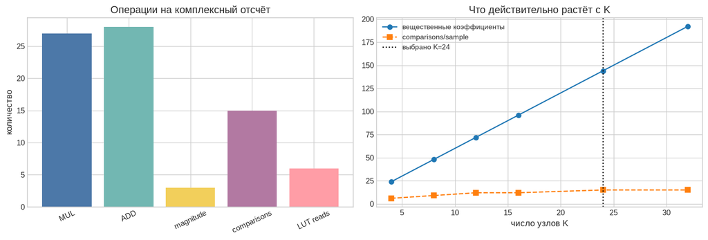

```python
# Визуальная раскладка операций и памяти выбранной конфигурации.
fig, axes = plt.subplots(1, 2, figsize=(12.8, 4.4))
operation_names = ["MUL", "ADD", "magnitude", "comparisons", "LUT reads"]
operation_values = [
    complexity["real_multiplications"],
    complexity["real_additions"],
    complexity["magnitude_operations"],
    complexity["comparisons"],
    complexity["LUT_reads"],
]
axes[0].bar(operation_names, operation_values,
            color=["#4C78A8", "#72B7B2", "#F2CF5B", "#B279A2", "#FF9DA6"])
axes[0].set(title="Операции на комплексный отсчёт", ylabel="количество")
axes[0].tick_params(axis="x", rotation=25)

k_values = np.array(K_CANDIDATES)
stored_reals = 2 * len(branches) * k_values
comparison_count = np.ceil(np.log2(k_values)).astype(int) * len({d for _, d in branches})
axes[1].plot(k_values, stored_reals, "o-", label="вещественные коэффициенты")
axes[1].plot(k_values, comparison_count, "s--", label="comparisons/sample")
axes[1].axvline(knot_count, color="black", ls=":", label=f"выбрано K={knot_count}")
axes[1].set(xlabel="число узлов K", title="Что действительно растёт с K")
axes[1].legend()
plt.tight_layout()
plt.show()
```

## 13. Потоковая реализация и воспроизводимость

Проверяются свойства, критичные для реального последовательного выполнения:

1. DPD получает `val_x`, а не measured `val_y`;
2. фазовая эквивариантность выполняется численно;
3. цельная и chunked обработка совпадают при переносе двух отсчётов истории;
4. состояние сбрасывается между независимыми records;
5. validation и predistorted drive не выходят за amplitude support train;
6. DPD действительно уменьшает ошибку frozen evaluator.

```python
# 1) Данные и модель конечны.
assert np.all(np.isfinite(train_x)) and np.all(np.isfinite(val_x))
assert np.all(np.isfinite(pa_coefficients)) and np.all(np.isfinite(refined_dpd_coefficients))
assert refined_dpd_coefficients.shape == (len(branches), knot_count)

# 2) Правильное deployment-направление: DPD получает val_x, а не val_y.
replay_from_desired = predict_spline_memory(val_x, knots, branches, refined_dpd_coefficients)
assert np.allclose(replay_from_desired, predistorted_refined_val)

# 3) Фазовая эквивариантность D(e^{jφ}x)=e^{jφ}D(x).
phi = 0.731
rotated = np.exp(1j * phi) * val_x[:4000]
lhs = predict_spline_memory(rotated, knots, branches, refined_dpd_coefficients)
rhs = np.exp(1j * phi) * predict_spline_memory(val_x[:4000], knots, branches, refined_dpd_coefficients)
assert np.max(np.abs(lhs - rhs)) < 1e-12

# 4) Потоковая проверка: разбиваем validation на произвольные chunks.
def predict_streaming(signal, chunk_sizes):
    """Run one independent record while carrying only causal history."""
    history_size = max(max(pair) for pair in branches)
    history = np.zeros(history_size, dtype=np.complex128)
    output = []
    start = 0
    for size in chunk_sizes:
        chunk = np.asarray(signal[start:start + size], dtype=np.complex128)
        padded = np.concatenate((history, chunk))
        piece = predict_spline_memory(padded, knots, branches, refined_dpd_coefficients)[history.size:]
        output.append(piece)
        history = padded[-history_size:] if history_size else history
        start += size
    if start < signal.size:
        chunk = np.asarray(signal[start:], dtype=np.complex128)
        padded = np.concatenate((history, chunk))
        output.append(predict_spline_memory(padded, knots, branches, refined_dpd_coefficients)[history_size:])
    return np.concatenate(output)


streamed = predict_streaming(val_x, [1, 8, 64, 257, 1024])
reference_stream = predict_spline_memory(val_x, knots, branches, refined_dpd_coefficients)
assert np.max(np.abs(streamed - reference_stream)) < 1e-12

# 5) Reset на границе независимого record: history train не попадает в validation.
record_a, record_b = val_x[:3000], val_x[3000:7000]
separate_b = predict_streaming(record_b, [17, 131, 509])
repeated_b = predict_streaming(record_b, [1, 29, 777])
direct_b = predict_spline_memory(record_b, knots, branches, refined_dpd_coefficients)
assert np.max(np.abs(separate_b - direct_b)) < 1e-12
assert np.max(np.abs(repeated_b - direct_b)) < 1e-12
concatenated = predict_spline_memory(np.concatenate((record_a, record_b)), knots, branches, refined_dpd_coefficients)
# При отсутствии reset первые memory samples второго record обычно отличаются.
assert np.max(np.abs(concatenated[record_a.size:record_a.size + DPD_WARMUP]
                     - direct_b[:DPD_WARMUP])) > 0

# 6) Никакого незаявленного extrapolation: validation desired и drive внутри train support.
assert np.max(np.abs(val_x)) <= knots[-1] * (1 + 1e-12)
assert np.max(np.abs(predistorted_refined_val)) <= np.max(np.abs(train_x)) * (1 + 1e-12)

# 7) DPD действительно уменьшает frozen-surrogate error power.
assert refined_mse < dpd_mse < no_dpd_mse
print("ALL SELF-TESTS PASSED")
print(f"phase equivariance max error: {np.max(np.abs(lhs-rhs)):.3e}")
print(f"streaming max error: {np.max(np.abs(streamed-reference_stream)):.3e}")
```

```
ALL SELF-TESTS PASSED
phase equivariance max error: 3.357e-16
streaming max error: 0.000e+00
```

```python
# Машиночитаемый итог validation-части полного запуска.
research_summary = {
    "dataset": "BlackBox capture",
    "train_samples": int(train_x.size),
    "validation_samples": int(val_x.size),
    "pa_evaluator_nmse_db": pooled_nmse_db(pa_val_hat, val_y, PA_WARMUP),
    "no_dpd_nmse_db": surrogate_no_dpd["nmse_db"],
    "ila_spline_nmse_db": dpd_metrics["nmse_db"],
    "direct_refined_nmse_db": refined_metrics["nmse_db"],
    "direct_gain_over_ila_db": direct_gain_over_ila_db,
    "direct_gain_over_no_dpd_db": direct_gain_over_no_dpd_db,
    "branches": branches,
    "knot_count": knot_count,
    "ila_ridge": ridge,
    "complexity": complexity,
    "segment_direct_gain_over_ila_db": segment_gain_ila_to_direct.tolist(),
    "streaming_max_error": float(np.max(np.abs(streamed - reference_stream))),
    "phase_equivariance_max_error": float(np.max(np.abs(lhs - rhs))),
    "direct_model_sha256": DIRECT_MODEL_SHA256,
}
print(json.dumps(research_summary, ensure_ascii=False, indent=2))
```

```
{
  "dataset": "BlackBox capture",
  "train_samples": 92000,
  "validation_samples": 23000,
  "pa_evaluator_nmse_db": -28.590449265757027,
  "no_dpd_nmse_db": -16.010350840472285,
  "ila_spline_nmse_db": -17.192240437598432,
  "direct_refined_nmse_db": -21.587580088478152,
  "direct_gain_over_ila_db": 4.39533965087972,
  "direct_gain_over_no_dpd_db": 5.577229248005867,
  "branches": [
    [
      0,
      0
    ],
    [
      1,
      1
    ],
    [
      2,
      2
    ]
  ],
  "knot_count": 24,
  "ila_ridge": 0.0001,
  "complexity": {
    "real_multiplications": 27,
    "real_additions": 28,
    "magnitude_operations": 3,
    "comparisons": 15,
    "LUT_reads": 6,
    "stored_complex_coefficients": 72,
    "stored_real_coefficients": 144,
    "state_complex_values": 2,
    "state_real_values": 4
  },
  "segment_direct_gain_over_ila_db": [
    4.560822597887139,
    4.257653550904312,
    4.399862316078259,
    4.430407176479701,
    4.423758816890388,
    4.257956529299218,
    4.40702276270385,
    4.407088868196325
  ],
  "streaming_max_error": 0.0,
  "phase_equivariance_max_error": 3.356589068483857e-16,
  "direct_model_sha256": "ddba7f70b63de3c9d3f72991f965a67b7f912795f1cea2556108e1a31a8eb222"
}
```

## 14. Untouched waveform и fixed-point

После выбора iterative direct-кандидата до test access были зафиксированы SHA-256 модели и evaluator, warm-up, число сегментов и acceptance gate. В one-shot процедуре открыт только desired $x_{test}$; measured $y_{test}$ не открывался. Это проверяет перенос на новую последовательность, но всё ещё через тот же software PA evaluator.

Fixed-point масштабы определены только по train. Проверяются 16/14/12-bit входы и коэффициенты, широкие аккумуляторы, насыщения, столкновения кодов узлов и точное совпадение цельной/кусковой обработки. Это bit-accurate Python reference, а не RTL/HLS timing.

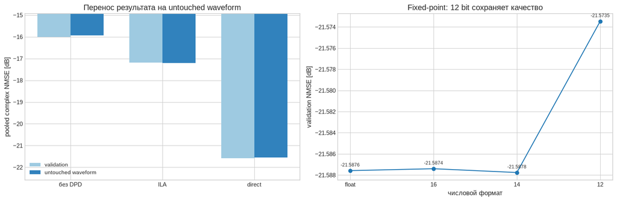

```
Untouched test gain over ILA: 4.336798 dB
Untouched test gain over no DPD: 5.608398 dB
Minimum test-segment gain over ILA: 4.243725 dB
12-bit degradation: 0.014125558795104354 dB
Test output opened: False
```

```python
# Агрегированные evidence-артефакты; test samples в notebook не встроены.
FIXED_JSON_B64 = """ewogICJzdGFnZSI6ICJpdGVyYXRpdmVfZGlyZWN0X2ZpeGVkX3BvaW50X3Zh…"""
FIXED_JSON_SHA256 = "fc1b4b7f7bd3791daba66c62df458f6842875ac0853eaf9e9e72a99da6800bce"
SEALED_JSON_B64 = """ewogICJzY2hlbWFfdmVyc2lvbiI6IDEsCiAgImFydGlmYWN0X3R5cGUiOiAi…=="""
SEALED_JSON_SHA256 = "6a52bc8605ced498eb656a3937b5047e51d65ee5bac0ef5bf72c6614b1044c07"
fixed_report = decode_json_payload(FIXED_JSON_B64, FIXED_JSON_SHA256)
sealed_report = decode_json_payload(SEALED_JSON_B64, SEALED_JSON_SHA256)

validation_scores = [surrogate_no_dpd["nmse_db"], dpd_metrics["nmse_db"],
                     refined_metrics["nmse_db"]]
sealed_scores = [
    sealed_report["metrics"]["no_dpd"]["pooled_complex_nmse_db"],
    sealed_report["metrics"]["ila_spline"]["pooled_complex_nmse_db"],
    sealed_report["metrics"]["iterative_direct_spline"]["pooled_complex_nmse_db"],
]

fig, axes = plt.subplots(1, 2, figsize=(14.5, 4.8))
positions = np.arange(3)
width = 0.36
axes[0].bar(positions - width/2, validation_scores, width=width,
            label="validation", color="#9ECAE1")
axes[0].bar(positions + width/2, sealed_scores, width=width,
            label="untouched waveform", color="#3182BD")
axes[0].set_xticks(positions, ["без DPD", "ILA", "direct"])
axes[0].set(ylabel="pooled complex NMSE [dB]",
            title="Перенос результата на untouched waveform")
axes[0].set_ylim(min(validation_scores + sealed_scores) - 1,
                 max(validation_scores + sealed_scores) + 1)
axes[0].legend()

bit_labels = ["float"] + [str(row["bits"]) for row in fixed_report["formats"]]
bit_nmse = [fixed_report["float_reference"]["cascade_nmse_db"]] + [
    row["cascade_nmse_db"] for row in fixed_report["formats"]
]
axes[1].plot(bit_labels, bit_nmse, "o-", color="tab:blue")
axes[1].set(xlabel="числовой формат", ylabel="validation NMSE [dB]",
            title="Fixed-point: 12 bit сохраняет качество")
for index, value in enumerate(bit_nmse):
    axes[1].annotate(f"{value:.4f}", (index, value), xytext=(0, 7),
                     textcoords="offset points", ha="center", fontsize=8)
plt.tight_layout()
plt.show()

assert sealed_report["acceptance_pass"]
assert sealed_report["test_output_opened"] is False
assert min(sealed_report["derived"]["segment_gains_over_ila_db"]) > 0
assert fixed_report["all_streaming_checks_passed"]
assert all(row["coefficient_saturation_count"] == 0 for row in fixed_report["formats"])
assert all(row["knot_code_collision_count"] == 0 for row in fixed_report["formats"])

print(f"Untouched test gain over ILA: {sealed_report['derived']['gain_over_ila_db']:.6f} dB")
print(f"Untouched test gain over no DPD: {sealed_report['derived']['gain_over_no_dpd_db']:.6f} dB")
print(f"Minimum test-segment gain over ILA: {min(sealed_report['derived']['segment_gains_over_ila_db']):.6f} dB")
print("12-bit degradation:",
      next(row["cascade_degradation_vs_float_db"] for row in fixed_report["formats"]
           if row["bits"] == 12), "dB")
print("Test output opened:", sealed_report["test_output_opened"])
```

## 15. Выводы

### Что показал эксперимент

- Наша трёхветвенная spline-memory DPD после начальной ILA-калибровки дала **−17.192 dB**, а direct refinement тех же коэффициентов этой же модели достиг **−21.588 dB** на validation: выигрыш **4.395 dB** без изменения fast path.
- Первое direct-обновление принесло основную часть выигрыша; три последующие итерации добавили только около 0.113 dB. Это признак насыщения локальной оптимизации, а не основание бесконечно увеличивать число итераций.
- На untouched waveform direct-кандидат получил **−21.545 dB** и сохранил преимущество над ILA во всех восьми последовательных сегментах.
- 12-bit integer reference ухудшил NMSE только примерно на **0.014 dB**; насыщений, knot collisions и streaming-расхождений не обнаружено.
- Дополнительные cross-memory, GMP residual, short FIR и другое размещение узлов дали отрицательный или слишком малый выигрыш относительно стоимости.

### Почему выбран именно этот подход

1. **Spline-memory core** сохраняет фазовую эквивариантность, локальную LUT- интерполяцию и прозрачную fixed-point стоимость.
2. **ILA** даёт быстрое устойчивое начальное решение линейной регрессией.
3. **Direct refinement** улучшает калибровку того же baseline и согласует его коэффициенты с реальной целью каскада, но не добавляет ни одной операции в sample-rate тракт.
4. **Ridge, bounded step и train-advisor split** ограничивают нестабильные направления Jacobian и отделяют расчёт обновления от выбора шага.
5. **AM/AM conditional bands и segment-wise NMSE** не скрывают память за одной усреднённой цифрой или красивой линией.
6. **One-shot test и fixed-point gates** проверяют перенос и числовую реализуемость до физического PA.

### Что пока не доказано

- подавление в официально определённых спектральных областях;
- результат после подачи predistorted drive на физический PA;
- независимость от ошибок GMP evaluator;
- RTL/HLS synthesis, latency и throughput;
- стандартная EVM без демодуляционного протокола.

## 16. Основные источники

1. D. R. Morgan, Z. Ma, J. Kim, M. G. Zierdt, J. Pastalan, “A Generalized Memory Polynomial Model for Digital Predistortion of RF Power Amplifiers,” *IEEE Transactions on Signal Processing*, 2006. [DOI](https://doi.org/10.1109/TSP.2006.879264)
2. C. Eun, E. J. Powers, “A New Volterra Predistorter Based on the Indirect Learning Architecture,” *IEEE Transactions on Signal Processing*, 1997. [DOI](https://doi.org/10.1109/78.552219)
3. P. P. Campo, A. Brihuega, L. Anttila, M. Turunen, D. Korpi, M. Allén, M. Valkama, “Gradient-Adaptive Spline-Interpolated LUT Methods for Low-Complexity Digital Predistortion,” *IEEE Transactions on Circuits and Systems I*, 2020. [arXiv](https://arxiv.org/abs/1907.02350) · [DOI](https://doi.org/10.1109/TCSI.2020.3034825)
4. Y. Wu, G. D. Singh, M. Beikmirza, L. C. N. de Vreede, M. Alavi, C. Gao, “OpenDPD: An Open-Source End-to-End Learning & Benchmarking Framework for Wideband Power Amplifier Modeling and Digital Pre-Distortion,” ISCAS 2024. [arXiv](https://arxiv.org/abs/2401.08318) · [официальный репозиторий](https://github.com/lab-emi/OpenDPD)
5. J. Wood, *Behavioral Modeling and Linearization of RF Power Amplifiers*, Artech House, 2014.

### Воспроизведение direct refinement

Из корня проекта:

```
python -m experiments.evaluate_blackbox_dpd_hypotheses --stage direct
python -m experiments.evaluate_blackbox_dpd_hypotheses --stage direct-robustness
python -m experiments.evaluate_blackbox_dpd_hypotheses --stage direct-iterative
python -m experiments.evaluate_blackbox_dpd_hypotheses --stage fixed-point
```

One-shot test повторно не запускается: его агрегированный отчёт уже связан с предварительной регистрацией и показан выше.